# Cars4u Case Study

## Context

- There is a huge demand for used cars in the Indian Market today. As sales of new cars have slowed down in the recent past, the pre-owned car market has continued to grow over the past years and is larger than the new car market now. Cars4U is a budding tech start-up that aims to find footholes in this market.
- In 2018-19, while new car sales were recorded at 3.6 million units, around 4 million second-hand cars were bought and sold. There is a slowdown in new car sales and that could mean that the demand is shifting towards the pre-owned market. In fact, some car sellers replace their old cars with pre-owned cars instead of buying new ones. Unlike new cars, where price and supply are fairly deterministic and managed by OEMs (Original Equipment Manufacturer / except for dealership level discounts which come into play only in the last stage of the customer journey), used cars are very different beasts with huge uncertainty in both pricing and supply. Keeping this in mind, the pricing scheme of these used cars becomes important in order to grow in the market.
- As a senior data scientist at Cars4U, you have to come up with a pricing model that can effectively predict the price of used cars and can help the business in devising profitable strategies using differential pricing. For example, if the business knows the market price, it will never sell anything below it.

## Objective

- To explore and visualize the dataset, build a linear regression model to predict the prices of used cars, and generate a set of insights and recommendations that will help the business.

## Data Description

- The data contains the different attributes of used cars sold in different locations. The detailed data dictionary is given below.

## Data Dictionary

- S.No.: Serial number
- Name: Name of the car which includes brand name and model name
- Location: Location in which the car is being sold or is available for purchase (cities)
- Year: Manufacturing year of the car
- Kilometers_driven: The total kilometers (a unit used to measure length or distance) driven in the car by the previous owner(s)
- Fuel_Type: The type of fuel used by the car (Petrol, Diesel, Electric, CNG, LPG)
- Transmission: The type of transmission used by the car (Automatic/Manual)
- Owner: Type of ownership
- Mileage: The standard mileage offered by the car company in kmpl or km/kg
- Engine: The displacement volume of the engine in CC
- Power: The maximum power of the engine in bhp
- Seats: The number of seats in the car
- New_Price: The price of a new car of the same model in INR Lakhs (1 Lakh INR = 100,000 INR)
- Price: The price of the used car in INR Lakhs

### Importing Libraries

```python
# libraries for manioulating and reading data
import pandas as pd
import numpy as np

# libraries for Visuals
import matplotlib.pyplot as plt
import seaborn as sns

# library for giving us full read option for columns
pd.set_option("display.max_columns", None)

# libraries for building and testing our model
from sklearn.model_selection import train_test_split
from sklearn.linear_model import LinearRegression
from sklearn.metrics import mean_absolute_error, mean_squared_error, r2_score
```

### Data information checks/ Data Validation

```python
# loading the data
data = pd.read_csv('used_cars_data.csv')
data.head()
```

|  | S.No. | Name | Location | Year | Kilometers_Driven | Fuel_Type | Transmission | Owner_Type | Mileage | Engine | Power | Seats | New_Price | Price |
| --- | --- | --- | --- | --- | --- | --- | --- | --- | --- | --- | --- | --- | --- | --- |
| 0 | 0 | Maruti Wagon R LXI CNG | Mumbai | 2010 | 72000 | CNG | Manual | First | 26.6 km/kg | 998 CC | 58.16 bhp | 5.0 | 5.51 | 1.75 |
| 1 | 1 | Hyundai Creta 1.6 CRDi SX Option | Pune | 2015 | 41000 | Diesel | Manual | First | 19.67 kmpl | 1582 CC | 126.2 bhp | 5.0 | 16.06 | 12.50 |
| 2 | 2 | Honda Jazz V | Chennai | 2011 | 46000 | Petrol | Manual | First | 18.2 kmpl | 1199 CC | 88.7 bhp | 5.0 | 8.61 | 4.50 |
| 3 | 3 | Maruti Ertiga VDI | Chennai | 2012 | 87000 | Diesel | Manual | First | 20.77 kmpl | 1248 CC | 88.76 bhp | 7.0 | 11.27 | 6.00 |
| 4 | 4 | Audi A4 New 2.0 TDI Multitronic | Coimbatore | 2013 | 40670 | Diesel | Automatic | Second | 15.2 kmpl | 1968 CC | 140.8 bhp | 5.0 | 53.14 | 17.74 |

```python
# shape of the data
print(f"There are {data.shape[0]} rows and {data.shape[1]} columns.")  # f-string
```

```
There are 7253 rows and 14 columns.
```

```python
# data types info
data.info()
```

```
<class 'pandas.core.frame.DataFrame'>
RangeIndex: 7253 entries, 0 to 7252
Data columns (total 14 columns):
 #   Column             Non-Null Count  Dtype
---  ------             --------------  -----
 0   S.No.              7253 non-null   int64
 1   Name               7253 non-null   object
 2   Location           7253 non-null   object
 3   Year               7253 non-null   int64
 4   Kilometers_Driven  7253 non-null   int64
 5   Fuel_Type          7253 non-null   object
 6   Transmission       7253 non-null   object
 7   Owner_Type         7253 non-null   object
 8   Mileage            7251 non-null   object
 9   Engine             7207 non-null   object
 10  Power              7078 non-null   object
 11  Seats              7200 non-null   float64
 12  New_Price          7253 non-null   float64
 13  Price              6019 non-null   float64
dtypes: float64(3), int64(3), object(8)
memory usage: 793.4+ KB
```

- The Data has 14 columns
- 8 columns being of the object data type, 3 integer type and 3 which are of the type float
- From the data info we can see that some columns have null values

```python
# describing data
data.describe(include = 'all').T
```

|  | count | unique | top | freq | mean | std | min | 25% | 50% | 75% | max |
| --- | --- | --- | --- | --- | --- | --- | --- | --- | --- | --- | --- |
| S.No. | 7253.0 | NaN | NaN | NaN | 3626.0 | 2093.905084 | 0.0 | 1813.0 | 3626.0 | 5439.0 | 7252.0 |
| Name | 7253 | 2041 | Mahindra XUV500 W8 2WD | 55 | NaN | NaN | NaN | NaN | NaN | NaN | NaN |
| Location | 7253 | 11 | Mumbai | 949 | NaN | NaN | NaN | NaN | NaN | NaN | NaN |
| Year | 7253.0 | NaN | NaN | NaN | 2013.365366 | 3.254421 | 1996.0 | 2011.0 | 2014.0 | 2016.0 | 2019.0 |
| Kilometers_Driven | 7253.0 | NaN | NaN | NaN | 58699.063146 | 84427.720583 | 171.0 | 34000.0 | 53416.0 | 73000.0 | 6500000.0 |
| Fuel_Type | 7253 | 5 | Diesel | 3852 | NaN | NaN | NaN | NaN | NaN | NaN | NaN |
| Transmission | 7253 | 2 | Manual | 5204 | NaN | NaN | NaN | NaN | NaN | NaN | NaN |
| Owner_Type | 7253 | 4 | First | 5952 | NaN | NaN | NaN | NaN | NaN | NaN | NaN |
| Mileage | 7251 | 450 | 17.0 kmpl | 207 | NaN | NaN | NaN | NaN | NaN | NaN | NaN |
| Engine | 7207 | 150 | 1197 CC | 732 | NaN | NaN | NaN | NaN | NaN | NaN | NaN |
| Power | 7078 | 385 | 74 bhp | 280 | NaN | NaN | NaN | NaN | NaN | NaN | NaN |
| Seats | 7200.0 | NaN | NaN | NaN | 5.279722 | 0.81166 | 0.0 | 5.0 | 5.0 | 5.0 | 10.0 |
| New_Price | 7253.0 | NaN | NaN | NaN | 21.307322 | 24.256314 | 3.91 | 7.88 | 11.3 | 21.69 | 375.0 |
| Price | 6019.0 | NaN | NaN | NaN | 9.479468 | 11.187917 | 0.44 | 3.5 | 5.64 | 9.95 | 160.0 |

- There are 11 different unique locations
- We have 5 different unique Fuel type, 2 different unique Transmissions and 4 unique owner type

```python
# checking for null
data.isnull().sum()
```

```
S.No.                   0
Name                    0
Location                0
Year                    0
Kilometers_Driven       0
Fuel_Type               0
Transmission            0
Owner_Type              0
Mileage                 2
Engine                 46
Power                 175
Seats                  53
New_Price               0
Price                1234
dtype: int64
```

```python
# checking for duplicates
data.duplicated().sum()
```

```
0
```

- There are no duplicates in the data

### Data Preprocessing

```python
# copying the data to keep the original
df = data.copy()
```

```python
df.head()
```

|  | S.No. | Name | Location | Year | Kilometers_Driven | Fuel_Type | Transmission | Owner_Type | Mileage | Engine | Power | Seats | New_Price | Price |
| --- | --- | --- | --- | --- | --- | --- | --- | --- | --- | --- | --- | --- | --- | --- |
| 0 | 0 | Maruti Wagon R LXI CNG | Mumbai | 2010 | 72000 | CNG | Manual | First | 26.6 km/kg | 998 CC | 58.16 bhp | 5.0 | 5.51 | 1.75 |
| 1 | 1 | Hyundai Creta 1.6 CRDi SX Option | Pune | 2015 | 41000 | Diesel | Manual | First | 19.67 kmpl | 1582 CC | 126.2 bhp | 5.0 | 16.06 | 12.50 |
| 2 | 2 | Honda Jazz V | Chennai | 2011 | 46000 | Petrol | Manual | First | 18.2 kmpl | 1199 CC | 88.7 bhp | 5.0 | 8.61 | 4.50 |
| 3 | 3 | Maruti Ertiga VDI | Chennai | 2012 | 87000 | Diesel | Manual | First | 20.77 kmpl | 1248 CC | 88.76 bhp | 7.0 | 11.27 | 6.00 |
| 4 | 4 | Audi A4 New 2.0 TDI Multitronic | Coimbatore | 2013 | 40670 | Diesel | Automatic | Second | 15.2 kmpl | 1968 CC | 140.8 bhp | 5.0 | 53.14 | 17.74 |

#### Data types check

```python
df.info()
```

```
<class 'pandas.core.frame.DataFrame'>
RangeIndex: 7253 entries, 0 to 7252
Data columns (total 14 columns):
 #   Column             Non-Null Count  Dtype
---  ------             --------------  -----
 0   S.No.              7253 non-null   int64
 1   Name               7253 non-null   object
 2   Location           7253 non-null   object
 3   Year               7253 non-null   int64
 4   Kilometers_Driven  7253 non-null   int64
 5   Fuel_Type          7253 non-null   object
 6   Transmission       7253 non-null   object
 7   Owner_Type         7253 non-null   object
 8   Mileage            7251 non-null   object
 9   Engine             7207 non-null   object
 10  Power              7078 non-null   object
 11  Seats              7200 non-null   float64
 12  New_Price          7253 non-null   float64
 13  Price              6019 non-null   float64
dtypes: float64(3), int64(3), object(8)
memory usage: 793.4+ KB
```

- From the data, we can see that Columns like Mileage,Engine and Power have numeric values but are being assigned the data type object. This is because these columns have some string values attached to their numeric values
- For the Model to be effective, it will be better to do away with these string values and convert the said columns into float values

```python
df['Mileage'].head(25)
```

```
0     26.6 km/kg
1     19.67 kmpl
2      18.2 kmpl
3     20.77 kmpl
4      15.2 kmpl
5     21.1 km/kg
6     23.08 kmpl
7     11.36 kmpl
8     20.54 kmpl
9      22.3 kmpl
10    21.56 kmpl
11     16.8 kmpl
12     25.2 kmpl
13     12.7 kmpl
14      0.0 kmpl
15     13.5 kmpl
16     25.8 kmpl
17     28.4 kmpl
18    20.45 kmpl
19    14.84 kmpl
20    22.69 kmpl
21    23.65 kmpl
22    13.53 kmpl
23     18.5 kmpl
24     14.4 kmpl
Name: Mileage, dtype: object
```

- We can see that Mileagw has both Km/kg and kmpl as its string values. We will need to first check which one is dominant

```python
kmkg = 0
kmpl = 0

for i in df.Mileage :
    if str(i).endswith('km/kg'):
        kmkg+=1
    elif str(i).endswith('kmpl'):
        kmpl+=1
print ('The number of rows witrh Km/kg : {}'.format(kmkg))
print ('The number of rows witrh Kmpl : {}'.format(kmpl))
```

```
The number of rows witrh Km/kg : 74
The number of rows witrh Kmpl : 7177
```

- There 74 rows with km/kg and 7177 as kmpl.
- We would have to convert those 74 to kmpl unit and convert them to floats but let us handle the null values first

```python
df['Mileage'].isnull().sum()
```

```
2
```

- Mileage has two nulls
- Lets drop them since two is null values is quite insignificant for now.
- In reality, we will need to visit our data engineers to verify what exactly these 2 null values but since we can not and its just two values we can drop them.

```python
df.dropna(subset=["Mileage"], inplace=True)

# let us reset the dataframe index
df.reset_index(inplace=True, drop=True)
```

```python
df.isnull().sum()
```

```
S.No.                   0
Name                    0
Location                0
Year                    0
Kilometers_Driven       0
Fuel_Type               0
Transmission            0
Owner_Type              0
Mileage                 0
Engine                 46
Power                 175
Seats                  53
New_Price               0
Price                1234
dtype: int64
```

```python
# Converting Mileage into a numerical column and also converting Km/kg to kmpl
Mileage_val = []

for i in df.Mileage:
    if str(i).endswith('km/kg'):
        i = i[:-6]
        i = float(i)*1.40
        Mileage_val.append(float(i))
    elif str(i).endswith('kmpl'):
        i= i[:-6]
        Mileage_val.append(float(i))
```

```python
df['Mileage'] = Mileage_val
```

```python
df.head()
```

|  | S.No. | Name | Location | Year | Kilometers_Driven | Fuel_Type | Transmission | Owner_Type | Mileage | Engine | Power | Seats | New_Price | Price |
| --- | --- | --- | --- | --- | --- | --- | --- | --- | --- | --- | --- | --- | --- | --- |
| 0 | 0 | Maruti Wagon R LXI CNG | Mumbai | 2010 | 72000 | CNG | Manual | First | 37.24 | 998 CC | 58.16 bhp | 5.0 | 5.51 | 1.75 |
| 1 | 1 | Hyundai Creta 1.6 CRDi SX Option | Pune | 2015 | 41000 | Diesel | Manual | First | 19.60 | 1582 CC | 126.2 bhp | 5.0 | 16.06 | 12.50 |
| 2 | 2 | Honda Jazz V | Chennai | 2011 | 46000 | Petrol | Manual | First | 18.00 | 1199 CC | 88.7 bhp | 5.0 | 8.61 | 4.50 |
| 3 | 3 | Maruti Ertiga VDI | Chennai | 2012 | 87000 | Diesel | Manual | First | 20.70 | 1248 CC | 88.76 bhp | 7.0 | 11.27 | 6.00 |
| 4 | 4 | Audi A4 New 2.0 TDI Multitronic | Coimbatore | 2013 | 40670 | Diesel | Automatic | Second | 15.00 | 1968 CC | 140.8 bhp | 5.0 | 53.14 | 17.74 |

```python
# function to convert Engine column into Numeric
def Engine_num(var):
    """
    This function takes in a string representing the Engine
    and converts it to a number. For example, '8CC' becomes 8.
    If the input is already numeric, which probably means it's NaN,
    this function just returns np.nan.
    """
    if isinstance (var,str):
        if var.endswith ('CC'):
            return float(var.replace('CC',''))
    else:
        return np.nan
```

```python
# Apply the function to our dataframe
df["Engine_CC"] = df["Engine"].apply(Engine_num)
df[["Engine_CC", "Engine"]].head()
```

|  | Engine_CC | Engine |
| --- | --- | --- |
| 0 | 998.0 | 998 CC |
| 1 | 1582.0 | 1582 CC |
| 2 | 1199.0 | 1199 CC |
| 3 | 1248.0 | 1248 CC |
| 4 | 1968.0 | 1968 CC |

```python
df.drop('Engine',axis=1,inplace=True)
```

```python
df.head()
```

|  | S.No. | Name | Location | Year | Kilometers_Driven | Fuel_Type | Transmission | Owner_Type | Mileage | Power | Seats | New_Price | Price | Engine_CC |
| --- | --- | --- | --- | --- | --- | --- | --- | --- | --- | --- | --- | --- | --- | --- |
| 0 | 0 | Maruti Wagon R LXI CNG | Mumbai | 2010 | 72000 | CNG | Manual | First | 37.24 | 58.16 bhp | 5.0 | 5.51 | 1.75 | 998.0 |
| 1 | 1 | Hyundai Creta 1.6 CRDi SX Option | Pune | 2015 | 41000 | Diesel | Manual | First | 19.60 | 126.2 bhp | 5.0 | 16.06 | 12.50 | 1582.0 |
| 2 | 2 | Honda Jazz V | Chennai | 2011 | 46000 | Petrol | Manual | First | 18.00 | 88.7 bhp | 5.0 | 8.61 | 4.50 | 1199.0 |
| 3 | 3 | Maruti Ertiga VDI | Chennai | 2012 | 87000 | Diesel | Manual | First | 20.70 | 88.76 bhp | 7.0 | 11.27 | 6.00 | 1248.0 |
| 4 | 4 | Audi A4 New 2.0 TDI Multitronic | Coimbatore | 2013 | 40670 | Diesel | Automatic | Second | 15.00 | 140.8 bhp | 5.0 | 53.14 | 17.74 | 1968.0 |

- Engine has no 'CC' attached to it which means the column was successfully converted

```python
# Converting Power Column into a numeric one
def Power_num(val):
    """
    This function takes in a string representing the Power
    and converts it to a number. For example, '8bhp' becomes 8.
    If the input is already numeric, which probably means it's NaN,
    this function just returns np.nan.
    """
    if isinstance (val,str):
        if val.endswith ('bhp'):
            return float(val.replace('bhp',''))
    else:
        return np.nan
```

```python
# Apply the function to our dataframe
df["Power_num"] = df["Power"].apply(Power_num)
df[["Power_num", "Power"]].head()
```

|  | Power_num | Power |
| --- | --- | --- |
| 0 | 58.16 | 58.16 bhp |
| 1 | 126.20 | 126.2 bhp |
| 2 | 88.70 | 88.7 bhp |
| 3 | 88.76 | 88.76 bhp |
| 4 | 140.80 | 140.8 bhp |

```python
df.drop('Power',axis=1,inplace=True)
```

```python
df.head()
```

|  | S.No. | Name | Location | Year | Kilometers_Driven | Fuel_Type | Transmission | Owner_Type | Mileage | Seats | New_Price | Price | Engine_CC | Power_num |
| --- | --- | --- | --- | --- | --- | --- | --- | --- | --- | --- | --- | --- | --- | --- |
| 0 | 0 | Maruti Wagon R LXI CNG | Mumbai | 2010 | 72000 | CNG | Manual | First | 37.24 | 5.0 | 5.51 | 1.75 | 998.0 | 58.16 |
| 1 | 1 | Hyundai Creta 1.6 CRDi SX Option | Pune | 2015 | 41000 | Diesel | Manual | First | 19.60 | 5.0 | 16.06 | 12.50 | 1582.0 | 126.20 |
| 2 | 2 | Honda Jazz V | Chennai | 2011 | 46000 | Petrol | Manual | First | 18.00 | 5.0 | 8.61 | 4.50 | 1199.0 | 88.70 |
| 3 | 3 | Maruti Ertiga VDI | Chennai | 2012 | 87000 | Diesel | Manual | First | 20.70 | 7.0 | 11.27 | 6.00 | 1248.0 | 88.76 |
| 4 | 4 | Audi A4 New 2.0 TDI Multitronic | Coimbatore | 2013 | 40670 | Diesel | Automatic | Second | 15.00 | 5.0 | 53.14 | 17.74 | 1968.0 | 140.80 |

- Power has no 'bhp' attached to it which means the column was successfully converted

```python
# checking for datatypes
df.info()
```

```
<class 'pandas.core.frame.DataFrame'>
RangeIndex: 7251 entries, 0 to 7250
Data columns (total 14 columns):
 #   Column             Non-Null Count  Dtype
---  ------             --------------  -----
 0   S.No.              7251 non-null   int64
 1   Name               7251 non-null   object
 2   Location           7251 non-null   object
 3   Year               7251 non-null   int64
 4   Kilometers_Driven  7251 non-null   int64
 5   Fuel_Type          7251 non-null   object
 6   Transmission       7251 non-null   object
 7   Owner_Type         7251 non-null   object
 8   Mileage            7251 non-null   float64
 9   Seats              7198 non-null   float64
 10  New_Price          7251 non-null   float64
 11  Price              6017 non-null   float64
 12  Engine_CC          7205 non-null   float64
 13  Power_num          7076 non-null   float64
dtypes: float64(6), int64(3), object(5)
memory usage: 793.2+ KB
```

- All the columns that were in the object data type have been successfully converted to Floats.

```python
df.describe(include = 'all').T
```

|  | count | unique | top | freq | mean | std | min | 25% | 50% | 75% | max |
| --- | --- | --- | --- | --- | --- | --- | --- | --- | --- | --- | --- |
| S.No. | 7251.0 | NaN | NaN | NaN | 3625.710661 | 2094.117927 | 0.0 | 1812.5 | 3625.0 | 5439.5 | 7252.0 |
| Name | 7251 | 2039 | Mahindra XUV500 W8 2WD | 55 | NaN | NaN | NaN | NaN | NaN | NaN | NaN |
| Location | 7251 | 11 | Mumbai | 948 | NaN | NaN | NaN | NaN | NaN | NaN | NaN |
| Year | 7251.0 | NaN | NaN | NaN | 2013.365329 | 3.254604 | 1996.0 | 2011.0 | 2014.0 | 2016.0 | 2019.0 |
| Kilometers_Driven | 7251.0 | NaN | NaN | NaN | 58702.290029 | 84439.126646 | 171.0 | 34000.0 | 53442.0 | 73000.0 | 6500000.0 |
| Fuel_Type | 7251 | 4 | Diesel | 3852 | NaN | NaN | NaN | NaN | NaN | NaN | NaN |
| Transmission | 7251 | 2 | Manual | 5204 | NaN | NaN | NaN | NaN | NaN | NaN | NaN |
| Owner_Type | 7251 | 4 | First | 5950 | NaN | NaN | NaN | NaN | NaN | NaN | NaN |
| Mileage | 7251.0 | NaN | NaN | NaN | 17.989708 | 4.84824 | 0.0 | 15.0 | 18.0 | 21.0 | 46.956 |
| Seats | 7198.0 | NaN | NaN | NaN | 5.2798 | 0.811759 | 0.0 | 5.0 | 5.0 | 5.0 | 10.0 |
| New_Price | 7251.0 | NaN | NaN | NaN | 21.308015 | 24.259469 | 3.91 | 7.88 | 11.3 | 21.535 | 375.0 |
| Price | 6017.0 | NaN | NaN | NaN | 9.47834 | 11.189605 | 0.44 | 3.5 | 5.64 | 9.95 | 160.0 |
| Engine_CC | 7205.0 | NaN | NaN | NaN | 1616.762665 | 595.085712 | 624.0 | 1198.0 | 1493.0 | 1968.0 | 5998.0 |
| Power_num | 7076.0 | NaN | NaN | NaN | 112.780976 | 53.492219 | 34.2 | 75.0 | 94.34 | 138.1 | 616.0 |

```python
df.drop('S.No.',axis=1,inplace=True)
```

```python
df.head()
```

|  | Name | Location | Year | Kilometers_Driven | Fuel_Type | Transmission | Owner_Type | Mileage | Seats | New_Price | Price | Engine_CC | Power_num |
| --- | --- | --- | --- | --- | --- | --- | --- | --- | --- | --- | --- | --- | --- |
| 0 | Maruti Wagon R LXI CNG | Mumbai | 2010 | 72000 | CNG | Manual | First | 37.24 | 5.0 | 5.51 | 1.75 | 998.0 | 58.16 |
| 1 | Hyundai Creta 1.6 CRDi SX Option | Pune | 2015 | 41000 | Diesel | Manual | First | 19.60 | 5.0 | 16.06 | 12.50 | 1582.0 | 126.20 |
| 2 | Honda Jazz V | Chennai | 2011 | 46000 | Petrol | Manual | First | 18.00 | 5.0 | 8.61 | 4.50 | 1199.0 | 88.70 |
| 3 | Maruti Ertiga VDI | Chennai | 2012 | 87000 | Diesel | Manual | First | 20.70 | 7.0 | 11.27 | 6.00 | 1248.0 | 88.76 |
| 4 | Audi A4 New 2.0 TDI Multitronic | Coimbatore | 2013 | 40670 | Diesel | Automatic | Second | 15.00 | 5.0 | 53.14 | 17.74 | 1968.0 | 140.80 |

### Handling Null Values

```python
df.isnull().sum()
```

```
Name                    0
Location                0
Year                    0
Kilometers_Driven       0
Fuel_Type               0
Transmission            0
Owner_Type              0
Mileage                 0
Seats                  53
New_Price               0
Price                1234
Engine_CC              46
Power_num             175
dtype: int64
```

- Only four columns have null values. Let us dive right in and deal with them

#### Dealing with Seats

```python
df['Seats'].nunique()
```

```
9
```

- There are nine unique values for seats

```python
df[df.Seats.isnull()]
```

|  | Name | Location | Year | Kilometers_Driven | Fuel_Type | Transmission | Owner_Type | Mileage | Seats | New_Price | Price | Engine_CC | Power_num |
| --- | --- | --- | --- | --- | --- | --- | --- | --- | --- | --- | --- | --- | --- |
| 194 | Honda City 1.5 GXI | Ahmedabad | 2007 | 60006 | Petrol | Manual | First | 0.0 | NaN | 13.580 | 2.95 | NaN | NaN |
| 208 | Maruti Swift 1.3 VXi | Kolkata | 2010 | 42001 | Petrol | Manual | First | 16.0 | NaN | 7.880 | 2.11 | NaN | NaN |
| 229 | Ford Figo Diesel | Bangalore | 2015 | 70436 | Diesel | Manual | First | 0.0 | NaN | 7.650 | 3.60 | 1498.0 | 99.0 |
| 733 | Maruti Swift 1.3 VXi | Chennai | 2006 | 97800 | Petrol | Manual | Third | 16.0 | NaN | 7.880 | 1.75 | NaN | NaN |
| 749 | Land Rover Range Rover 3.0 D | Mumbai | 2008 | 55001 | Diesel | Automatic | Second | 0.0 | NaN | 120.000 | 26.50 | NaN | NaN |
| 1294 | Honda City 1.3 DX | Delhi | 2009 | 55005 | Petrol | Manual | First | 12.0 | NaN | 13.580 | 3.20 | NaN | NaN |
| 1327 | Maruti Swift 1.3 ZXI | Hyderabad | 2015 | 50295 | Petrol | Manual | First | 16.0 | NaN | 7.880 | 5.80 | NaN | NaN |
| 1385 | Honda City 1.5 GXI | Pune | 2004 | 115000 | Petrol | Manual | Second | 0.0 | NaN | 13.580 | 1.50 | NaN | NaN |
| 1460 | Land Rover Range Rover Sport 2005 2012 Sport | Coimbatore | 2008 | 69078 | Petrol | Manual | First | 0.0 | NaN | 120.000 | 40.88 | NaN | NaN |
| 1917 | Honda City 1.5 EXI | Jaipur | 2005 | 88000 | Petrol | Manual | Second | 13.0 | NaN | 13.580 | 1.70 | 1493.0 | 100.0 |
| 2074 | Maruti Swift 1.3 LXI | Pune | 2011 | 24255 | Petrol | Manual | First | 16.0 | NaN | 7.880 | 3.15 | NaN | NaN |
| 2096 | Hyundai Santro LP zipPlus | Coimbatore | 2004 | 52146 | Petrol | Manual | First | 0.0 | NaN | 4.550 | 1.93 | NaN | NaN |
| 2264 | Toyota Etios Liva V | Pune | 2012 | 24500 | Petrol | Manual | Second | 18.0 | NaN | 8.525 | 2.95 | NaN | NaN |
| 2325 | Maruti Swift 1.3 VXI ABS | Pune | 2015 | 67000 | Petrol | Manual | First | 16.0 | NaN | 7.880 | 4.70 | NaN | NaN |
| 2335 | Maruti Swift 1.3 VXi | Mumbai | 2007 | 55000 | Petrol | Manual | Second | 16.0 | NaN | 7.880 | 1.75 | NaN | NaN |
| 2369 | Maruti Estilo LXI | Chennai | 2008 | 56000 | Petrol | Manual | Second | 19.0 | NaN | 7.880 | 1.50 | 1061.0 | NaN |
| 2530 | BMW 5 Series 520d Sedan | Kochi | 2014 | 64158 | Diesel | Automatic | First | 18.4 | NaN | 67.870 | 17.89 | NaN | NaN |
| 2542 | Hyundai Santro GLS II - Euro II | Bangalore | 2011 | 65000 | Petrol | Manual | Second | 0.0 | NaN | 4.550 | 3.15 | NaN | NaN |
| 2623 | BMW 5 Series 520d Sedan | Pune | 2012 | 95000 | Diesel | Automatic | Second | 18.4 | NaN | 67.870 | 18.00 | NaN | NaN |
| 2668 | Maruti Swift 1.3 VXi | Kolkata | 2014 | 32986 | Petrol | Manual | First | 16.0 | NaN | 7.880 | 4.24 | NaN | NaN |
| 2737 | Maruti Wagon R Vx | Jaipur | 2001 | 200000 | Petrol | Manual | First | 12.0 | NaN | 5.510 | 0.70 | NaN | NaN |
| 2780 | Hyundai Santro GLS II - Euro II | Pune | 2009 | 100000 | Petrol | Manual | First | 0.0 | NaN | 4.550 | 1.60 | NaN | NaN |
| 2842 | Hyundai Santro GLS II - Euro II | Bangalore | 2012 | 43000 | Petrol | Manual | First | 0.0 | NaN | 4.550 | 3.25 | NaN | NaN |
| 3272 | BMW 5 Series 520d Sedan | Mumbai | 2008 | 81000 | Diesel | Automatic | Second | 18.4 | NaN | 67.870 | 10.50 | NaN | NaN |
| 3404 | Maruti Swift 1.3 VXi | Jaipur | 2006 | 125000 | Petrol | Manual | Fourth & Above | 16.0 | NaN | 7.880 | 2.35 | NaN | NaN |
| 3520 | BMW 5 Series 520d Sedan | Delhi | 2012 | 90000 | Diesel | Automatic | First | 18.4 | NaN | 67.870 | 14.50 | NaN | NaN |
| 3522 | Hyundai Santro GLS II - Euro II | Kochi | 2012 | 66400 | Petrol | Manual | First | 0.0 | NaN | 4.550 | 2.66 | NaN | NaN |
| 3800 | Ford Endeavour Hurricane LE | Mumbai | 2012 | 129000 | Diesel | Automatic | First | 12.0 | NaN | 35.290 | 7.00 | 2953.0 | NaN |
| 3810 | Honda CR-V AT With Sun Roof | Kolkata | 2013 | 27000 | Petrol | Automatic | First | 14.0 | NaN | 33.510 | 11.99 | NaN | NaN |
| 3882 | Maruti Estilo LXI | Kolkata | 2010 | 40000 | Petrol | Manual | Second | 19.0 | NaN | 7.880 | 2.50 | 1061.0 | NaN |
| 4011 | Fiat Punto 1.3 Emotion | Pune | 2011 | 45271 | Diesel | Manual | First | 20.0 | NaN | 8.600 | 2.60 | NaN | NaN |
| 4152 | Land Rover Range Rover 3.0 D | Mumbai | 2003 | 75000 | Diesel | Automatic | Second | 0.0 | NaN | 120.000 | 16.11 | NaN | NaN |
| 4229 | Hyundai Santro Xing XG | Bangalore | 2005 | 79000 | Petrol | Manual | Second | 17.0 | NaN | 4.550 | 1.65 | NaN | NaN |
| 4576 | BMW 5 Series 520d Sedan | Delhi | 2012 | 72000 | Diesel | Automatic | Third | 18.4 | NaN | 67.870 | 13.85 | NaN | NaN |
| 4603 | Honda Jazz Select Edition | Pune | 2011 | 98000 | Petrol | Manual | First | 16.0 | NaN | 9.600 | 3.15 | NaN | NaN |
| 4696 | Fiat Punto 1.2 Dynamic | Kochi | 2017 | 17941 | Petrol | Manual | First | 15.0 | NaN | 8.600 | 3.93 | NaN | NaN |
| 4711 | Hyundai Santro Xing XG | Pune | 2003 | 80000 | Petrol | Manual | Second | 17.0 | NaN | 4.550 | 0.90 | NaN | NaN |
| 4950 | Fiat Punto 1.4 Emotion | Kolkata | 2010 | 47000 | Petrol | Manual | First | 14.0 | NaN | 8.600 | 1.49 | NaN | NaN |
| 5013 | Maruti Swift 1.3 VXi | Delhi | 2006 | 63000 | Petrol | Manual | First | 16.0 | NaN | 7.880 | 1.60 | NaN | NaN |
| 5183 | Maruti Swift 1.3 LXI | Delhi | 2012 | 52000 | Petrol | Manual | First | 16.0 | NaN | 7.880 | 3.65 | NaN | NaN |
| 5268 | Honda City 1.5 GXI | Bangalore | 2002 | 53000 | Petrol | Manual | Second | 0.0 | NaN | 13.580 | 1.85 | NaN | NaN |
| 5891 | Maruti Estilo LXI | Chennai | 2008 | 51000 | Petrol | Manual | Second | 19.0 | NaN | 7.880 | 1.75 | 1061.0 | NaN |
| 6040 | Skoda Laura 1.8 TSI Ambition | Bangalore | 2009 | 72000 | Petrol | Manual | Second | 17.0 | NaN | 25.830 | NaN | NaN | NaN |
| 6539 | Toyota Etios Liva Diesel TRD Sportivo | Bangalore | 2012 | 56600 | Diesel | Manual | First | 23.5 | NaN | 8.525 | NaN | NaN | NaN |
| 6542 | Hyundai i20 new Sportz AT 1.4 | Bangalore | 2012 | 58000 | Petrol | Automatic | Second | 15.0 | NaN | 10.250 | NaN | NaN | NaN |
| 6631 | Mahindra TUV 300 P4 | Kolkata | 2016 | 27000 | Diesel | Manual | First | 0.0 | NaN | 18.865 | NaN | NaN | NaN |
| 6641 | BMW 5 Series 520d Sedan | Bangalore | 2009 | 150000 | Diesel | Automatic | Second | 18.4 | NaN | 67.870 | NaN | NaN | NaN |
| 6649 | Maruti Swift 1.3 VXi | Kolkata | 2015 | 36009 | Petrol | Manual | First | 16.0 | NaN | 7.880 | NaN | NaN | NaN |
| 6675 | Fiat Punto 1.4 Emotion | Jaipur | 2010 | 65000 | Petrol | Manual | Third | 14.0 | NaN | 8.600 | NaN | NaN | NaN |
| 6683 | Maruti Swift 1.3 VXi | Pune | 2010 | 115000 | Petrol | Manual | Second | 16.0 | NaN | 7.880 | NaN | NaN | NaN |
| 6878 | BMW 5 Series 520d Sedan | Chennai | 2009 | 95000 | Diesel | Automatic | Second | 18.4 | NaN | 67.870 | NaN | NaN | NaN |
| 6900 | Toyota Etios Liva V | Kochi | 2012 | 59311 | Petrol | Manual | First | 18.0 | NaN | 8.525 | NaN | NaN | NaN |
| 6955 | Honda Jazz 2020 Petrol | Kochi | 2019 | 11574 | Petrol | Manual | First | 0.0 | NaN | 9.600 | NaN | 1199.0 | 88.7 |

```python
# Statistical view of Seats column
df.Seats.describe()
```

```
count    7198.000000
mean        5.279800
std         0.811759
min         0.000000
25%         5.000000
50%         5.000000
75%         5.000000
max        10.000000
Name: Seats, dtype: float64
```

- The Mean and the Median are very close in the context of the column Seats.
- We will take the Median of the Column and replace them with the Null Values.

```python
Median_Seats_C=df['Seats'].median()
```

```python
Median_Seats_C
```

```
5.0
```

```python
 # Replacing the values with the Median of Seats
df["Seats"].fillna(Median_Seats_C, inplace=True)
```

```python
df.isnull().sum()
```

```
Name                    0
Location                0
Year                    0
Kilometers_Driven       0
Fuel_Type               0
Transmission            0
Owner_Type              0
Mileage                 0
Seats                   0
New_Price               0
Price                1234
Engine_CC              46
Power_num             175
dtype: int64
```

- Seats column has no null values which means we have successfully dealt with the Null values
- Price column has 1234 missing values. This column is our target Variable
- Unless you are sure of what to impute when dealing with missing values for target variables, the best option is always to delete them.
- So we will delete all Null values for our Target Variable.

#### Dealing With Price

```python
# Deleting all null values from our target variable
df.dropna(subset=["Price"], inplace=True)
```

```python
df.isnull().sum()
```

```
Name                   0
Location               0
Year                   0
Kilometers_Driven      0
Fuel_Type              0
Transmission           0
Owner_Type             0
Mileage                0
Seats                  0
New_Price              0
Price                  0
Engine_CC             36
Power_num            143
dtype: int64
```

- The null values in our target variable has been dealth with succesfully
- Next Up is Engine which has 36 Null Values.
- Let us get some insights on this

#### Dealing With Engine

```python
df[df.Engine_CC.isnull()]
```

|  | Name | Location | Year | Kilometers_Driven | Fuel_Type | Transmission | Owner_Type | Mileage | Seats | New_Price | Price | Engine_CC | Power_num |
| --- | --- | --- | --- | --- | --- | --- | --- | --- | --- | --- | --- | --- | --- |
| 194 | Honda City 1.5 GXI | Ahmedabad | 2007 | 60006 | Petrol | Manual | First | 0.0 | 5.0 | 13.580 | 2.95 | NaN | NaN |
| 208 | Maruti Swift 1.3 VXi | Kolkata | 2010 | 42001 | Petrol | Manual | First | 16.0 | 5.0 | 7.880 | 2.11 | NaN | NaN |
| 733 | Maruti Swift 1.3 VXi | Chennai | 2006 | 97800 | Petrol | Manual | Third | 16.0 | 5.0 | 7.880 | 1.75 | NaN | NaN |
| 749 | Land Rover Range Rover 3.0 D | Mumbai | 2008 | 55001 | Diesel | Automatic | Second | 0.0 | 5.0 | 120.000 | 26.50 | NaN | NaN |
| 1294 | Honda City 1.3 DX | Delhi | 2009 | 55005 | Petrol | Manual | First | 12.0 | 5.0 | 13.580 | 3.20 | NaN | NaN |
| 1327 | Maruti Swift 1.3 ZXI | Hyderabad | 2015 | 50295 | Petrol | Manual | First | 16.0 | 5.0 | 7.880 | 5.80 | NaN | NaN |
| 1385 | Honda City 1.5 GXI | Pune | 2004 | 115000 | Petrol | Manual | Second | 0.0 | 5.0 | 13.580 | 1.50 | NaN | NaN |
| 1460 | Land Rover Range Rover Sport 2005 2012 Sport | Coimbatore | 2008 | 69078 | Petrol | Manual | First | 0.0 | 5.0 | 120.000 | 40.88 | NaN | NaN |
| 2074 | Maruti Swift 1.3 LXI | Pune | 2011 | 24255 | Petrol | Manual | First | 16.0 | 5.0 | 7.880 | 3.15 | NaN | NaN |
| 2096 | Hyundai Santro LP zipPlus | Coimbatore | 2004 | 52146 | Petrol | Manual | First | 0.0 | 5.0 | 4.550 | 1.93 | NaN | NaN |
| 2264 | Toyota Etios Liva V | Pune | 2012 | 24500 | Petrol | Manual | Second | 18.0 | 5.0 | 8.525 | 2.95 | NaN | NaN |
| 2325 | Maruti Swift 1.3 VXI ABS | Pune | 2015 | 67000 | Petrol | Manual | First | 16.0 | 5.0 | 7.880 | 4.70 | NaN | NaN |
| 2335 | Maruti Swift 1.3 VXi | Mumbai | 2007 | 55000 | Petrol | Manual | Second | 16.0 | 5.0 | 7.880 | 1.75 | NaN | NaN |
| 2530 | BMW 5 Series 520d Sedan | Kochi | 2014 | 64158 | Diesel | Automatic | First | 18.4 | 5.0 | 67.870 | 17.89 | NaN | NaN |
| 2542 | Hyundai Santro GLS II - Euro II | Bangalore | 2011 | 65000 | Petrol | Manual | Second | 0.0 | 5.0 | 4.550 | 3.15 | NaN | NaN |
| 2623 | BMW 5 Series 520d Sedan | Pune | 2012 | 95000 | Diesel | Automatic | Second | 18.4 | 5.0 | 67.870 | 18.00 | NaN | NaN |
| 2668 | Maruti Swift 1.3 VXi | Kolkata | 2014 | 32986 | Petrol | Manual | First | 16.0 | 5.0 | 7.880 | 4.24 | NaN | NaN |
| 2737 | Maruti Wagon R Vx | Jaipur | 2001 | 200000 | Petrol | Manual | First | 12.0 | 5.0 | 5.510 | 0.70 | NaN | NaN |
| 2780 | Hyundai Santro GLS II - Euro II | Pune | 2009 | 100000 | Petrol | Manual | First | 0.0 | 5.0 | 4.550 | 1.60 | NaN | NaN |
| 2842 | Hyundai Santro GLS II - Euro II | Bangalore | 2012 | 43000 | Petrol | Manual | First | 0.0 | 5.0 | 4.550 | 3.25 | NaN | NaN |
| 3272 | BMW 5 Series 520d Sedan | Mumbai | 2008 | 81000 | Diesel | Automatic | Second | 18.4 | 5.0 | 67.870 | 10.50 | NaN | NaN |
| 3404 | Maruti Swift 1.3 VXi | Jaipur | 2006 | 125000 | Petrol | Manual | Fourth & Above | 16.0 | 5.0 | 7.880 | 2.35 | NaN | NaN |
| 3520 | BMW 5 Series 520d Sedan | Delhi | 2012 | 90000 | Diesel | Automatic | First | 18.4 | 5.0 | 67.870 | 14.50 | NaN | NaN |
| 3522 | Hyundai Santro GLS II - Euro II | Kochi | 2012 | 66400 | Petrol | Manual | First | 0.0 | 5.0 | 4.550 | 2.66 | NaN | NaN |
| 3810 | Honda CR-V AT With Sun Roof | Kolkata | 2013 | 27000 | Petrol | Automatic | First | 14.0 | 5.0 | 33.510 | 11.99 | NaN | NaN |
| 4011 | Fiat Punto 1.3 Emotion | Pune | 2011 | 45271 | Diesel | Manual | First | 20.0 | 5.0 | 8.600 | 2.60 | NaN | NaN |
| 4152 | Land Rover Range Rover 3.0 D | Mumbai | 2003 | 75000 | Diesel | Automatic | Second | 0.0 | 5.0 | 120.000 | 16.11 | NaN | NaN |
| 4229 | Hyundai Santro Xing XG | Bangalore | 2005 | 79000 | Petrol | Manual | Second | 17.0 | 5.0 | 4.550 | 1.65 | NaN | NaN |
| 4576 | BMW 5 Series 520d Sedan | Delhi | 2012 | 72000 | Diesel | Automatic | Third | 18.4 | 5.0 | 67.870 | 13.85 | NaN | NaN |
| 4603 | Honda Jazz Select Edition | Pune | 2011 | 98000 | Petrol | Manual | First | 16.0 | 5.0 | 9.600 | 3.15 | NaN | NaN |
| 4696 | Fiat Punto 1.2 Dynamic | Kochi | 2017 | 17941 | Petrol | Manual | First | 15.0 | 5.0 | 8.600 | 3.93 | NaN | NaN |
| 4711 | Hyundai Santro Xing XG | Pune | 2003 | 80000 | Petrol | Manual | Second | 17.0 | 5.0 | 4.550 | 0.90 | NaN | NaN |
| 4950 | Fiat Punto 1.4 Emotion | Kolkata | 2010 | 47000 | Petrol | Manual | First | 14.0 | 5.0 | 8.600 | 1.49 | NaN | NaN |
| 5013 | Maruti Swift 1.3 VXi | Delhi | 2006 | 63000 | Petrol | Manual | First | 16.0 | 5.0 | 7.880 | 1.60 | NaN | NaN |
| 5183 | Maruti Swift 1.3 LXI | Delhi | 2012 | 52000 | Petrol | Manual | First | 16.0 | 5.0 | 7.880 | 3.65 | NaN | NaN |
| 5268 | Honda City 1.5 GXI | Bangalore | 2002 | 53000 | Petrol | Manual | Second | 0.0 | 5.0 | 13.580 | 1.85 | NaN | NaN |

```python
# Statistical View of Engine
df.Engine_CC.describe()
```

```
count    5981.000000
mean     1621.505935
std       601.117630
min       624.000000
25%      1198.000000
50%      1493.000000
75%      1984.000000
max      5998.000000
Name: Engine_CC, dtype: float64
```

- We will take the Median of the Column and replace them with the Null Values.

```python
Median_Engine = df['Engine_CC'].median()
```

```python
Median_Engine
```

```
1493.0
```

```python
#Replacing Null values for Engine
df["Engine_CC"].fillna(Median_Engine, inplace=True)
```

```python
df.isnull().sum()
```

```
Name                   0
Location               0
Year                   0
Kilometers_Driven      0
Fuel_Type              0
Transmission           0
Owner_Type             0
Mileage                0
Seats                  0
New_Price              0
Price                  0
Engine_CC              0
Power_num            143
dtype: int64
```

- We are down to the Power which has 143 null values.
- Lets get some insights on the column

#### Dealing with Power

```python
df[df.Power_num.isnull()]
```

|  | Name | Location | Year | Kilometers_Driven | Fuel_Type | Transmission | Owner_Type | Mileage | Seats | New_Price | Price | Engine_CC | Power_num |
| --- | --- | --- | --- | --- | --- | --- | --- | --- | --- | --- | --- | --- | --- |
| 76 | Ford Fiesta 1.4 SXi TDCi | Jaipur | 2008 | 111111 | Diesel | Manual | First | 17.0 | 5.0 | 11.685 | 2.00 | 1399.0 | NaN |
| 79 | Hyundai Santro Xing XL | Hyderabad | 2005 | 87591 | Petrol | Manual | First | 0.0 | 5.0 | 4.550 | 1.30 | 1086.0 | NaN |
| 89 | Hyundai Santro Xing XO | Hyderabad | 2007 | 73745 | Petrol | Manual | First | 17.0 | 5.0 | 4.550 | 2.10 | 1086.0 | NaN |
| 120 | Hyundai Santro Xing XL eRLX Euro III | Mumbai | 2005 | 102000 | Petrol | Manual | Second | 17.0 | 5.0 | 4.550 | 0.85 | 1086.0 | NaN |
| 143 | Hyundai Santro Xing XO eRLX Euro II | Kochi | 2008 | 80759 | Petrol | Manual | Third | 17.0 | 5.0 | 4.550 | 1.67 | 1086.0 | NaN |
| ... | ... | ... | ... | ... | ... | ... | ... | ... | ... | ... | ... | ... | ... |
| 5871 | Hyundai Santro Xing XO eRLX Euro II | Pune | 2006 | 47200 | Petrol | Manual | Second | 17.0 | 5.0 | 4.550 | 1.20 | 1086.0 | NaN |
| 5891 | Maruti Estilo LXI | Chennai | 2008 | 51000 | Petrol | Manual | Second | 19.0 | 5.0 | 7.880 | 1.75 | 1061.0 | NaN |
| 5923 | Skoda Laura Classic 1.8 TSI | Pune | 2010 | 85000 | Petrol | Manual | First | 17.0 | 5.0 | 25.830 | 2.85 | 1798.0 | NaN |
| 5941 | Mahindra Jeep MM 540 DP | Chennai | 2002 | 75000 | Diesel | Manual | First | 0.0 | 6.0 | 18.865 | 1.70 | 2112.0 | NaN |
| 5983 | Toyota Etios GD | Delhi | 2013 | 70000 | Diesel | Manual | First | 23.5 | 5.0 | 8.525 | 3.88 | 1364.0 | NaN |

143 rows × 13 columns

```python
#Statistical View of Power
df.Power_num.describe()
```

```
count    5874.000000
mean      113.272203
std        53.873317
min        34.200000
25%        75.000000
50%        97.700000
75%       138.100000
max       560.000000
Name: Power_num, dtype: float64
```

- We will take the Median of the Column and replace them with the Null Values.

```python
Median_Power = df['Power_num'].median()
```

```python
Median_Power
```

```
97.7
```

```python
# Replacing Null values for Power
df["Power_num"].fillna(Median_Power, inplace=True)
```

```python
# Checking for null Values
df.isnull().sum()
```

```
Name                 0
Location             0
Year                 0
Kilometers_Driven    0
Fuel_Type            0
Transmission         0
Owner_Type           0
Mileage              0
Seats                0
New_Price            0
Price                0
Engine_CC            0
Power_num            0
dtype: int64
```

- All Null Values have been dealt with and the data has no null values as seen above

```python
df.head(10)
```

|  | Name | Location | Year | Kilometers_Driven | Fuel_Type | Transmission | Owner_Type | Mileage | Seats | New_Price | Price | Engine_CC | Power_num |
| --- | --- | --- | --- | --- | --- | --- | --- | --- | --- | --- | --- | --- | --- |
| 0 | Maruti Wagon R LXI CNG | Mumbai | 2010 | 72000 | CNG | Manual | First | 37.24 | 5.0 | 5.51 | 1.75 | 998.0 | 58.16 |
| 1 | Hyundai Creta 1.6 CRDi SX Option | Pune | 2015 | 41000 | Diesel | Manual | First | 19.60 | 5.0 | 16.06 | 12.50 | 1582.0 | 126.20 |
| 2 | Honda Jazz V | Chennai | 2011 | 46000 | Petrol | Manual | First | 18.00 | 5.0 | 8.61 | 4.50 | 1199.0 | 88.70 |
| 3 | Maruti Ertiga VDI | Chennai | 2012 | 87000 | Diesel | Manual | First | 20.70 | 7.0 | 11.27 | 6.00 | 1248.0 | 88.76 |
| 4 | Audi A4 New 2.0 TDI Multitronic | Coimbatore | 2013 | 40670 | Diesel | Automatic | Second | 15.00 | 5.0 | 53.14 | 17.74 | 1968.0 | 140.80 |
| 5 | Hyundai EON LPG Era Plus Option | Hyderabad | 2012 | 75000 | LPG | Manual | First | 29.54 | 5.0 | 10.25 | 2.35 | 814.0 | 55.20 |
| 6 | Nissan Micra Diesel XV | Jaipur | 2013 | 86999 | Diesel | Manual | First | 23.00 | 5.0 | 9.47 | 3.50 | 1461.0 | 63.10 |
| 7 | Toyota Innova Crysta 2.8 GX AT 8S | Mumbai | 2016 | 36000 | Diesel | Automatic | First | 11.30 | 8.0 | 21.00 | 17.50 | 2755.0 | 171.50 |
| 8 | Volkswagen Vento Diesel Comfortline | Pune | 2013 | 64430 | Diesel | Manual | First | 20.50 | 5.0 | 13.23 | 5.20 | 1598.0 | 103.60 |
| 9 | Tata Indica Vista Quadrajet LS | Chennai | 2012 | 65932 | Diesel | Manual | Second | 22.00 | 5.0 | 7.63 | 1.95 | 1248.0 | 74.00 |

### UNIVARIATE ANALYSIS

#### Let's check the distribution for numerical columns.

#### Year of Manufacturing

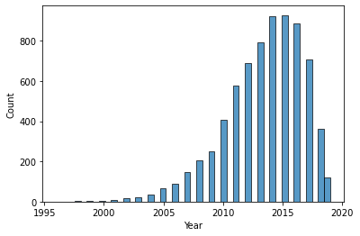

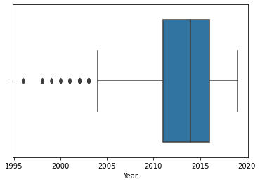

```python
sns.histplot(data=data,x='Year')
plt.show()
sns.boxplot(data=data,x='Year')
plt.show()
```

- A lot of cars were manufactured between the years 2012-2017
- The years 2014 and 2015 recorded the highest number of cars manufactured.
- The lowest rate of manufacturing cars was recorded before 2005.
- From our boxplot, we can see that there are some few outliers which fall between 1995-2005

#### Kilometeres driven

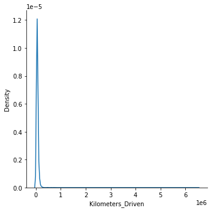

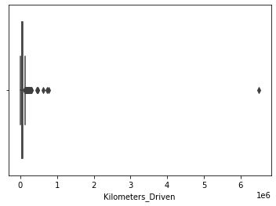

```python
sns.displot(data=df,x='Kilometers_Driven',kind='kde')
plt.show()
sns.boxplot(data=df,x='Kilometers_Driven')
plt.show()
```

- The plot above shows us that the data is heavily right-skewed
- From the box plot the data is also right skewed and there are a lot of outliers.
- We will look at other columns and see if we have columns like that.

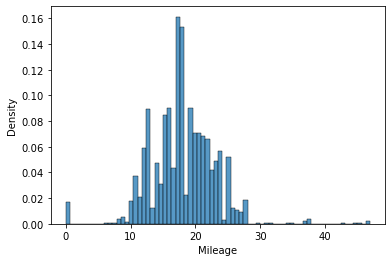

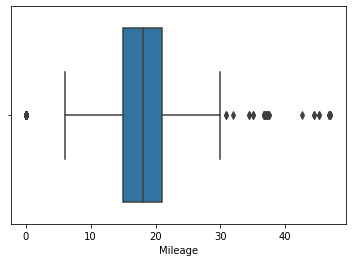

```python
sns.histplot(data=df,x='Mileage',stat='density')
plt.show()
sns.boxplot(data=df,x='Mileage')
plt.show()
```

- The Mileage distribution is not heavily left or right skewed.
- There are some outliers which we will need to deal with
- We can see the Mean,median and Max value

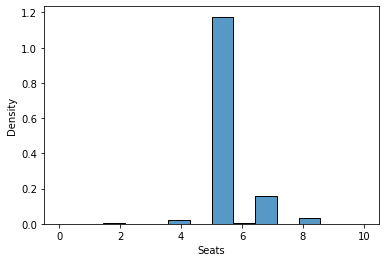

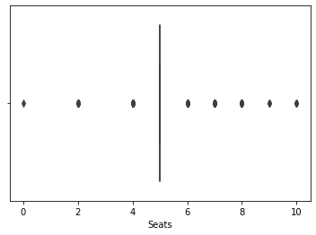

```python
sns.histplot(data=df,x='Seats',stat='density')
plt.show()
sns.boxplot(data=df,x='Seats')
plt.show()
```

```python
df.Seats.value_counts()
```

```
5.0     5054
7.0      674
8.0      134
4.0       99
6.0       31
2.0       16
10.0       5
9.0        3
0.0        1
Name: Seats, dtype: int64
```

- The plot shows us that majority of the data is between Seats 4-6.
- Therefore and the outliers are also affecting the plot.
- Let us take a statistical view again to understand

```python
df.Seats.describe()
```

```
count    6017.000000
mean        5.276882
std         0.806464
min         0.000000
25%         5.000000
50%         5.000000
75%         5.000000
max        10.000000
Name: Seats, dtype: float64
```

- From the statistical viee, the 25th percentile - 75th percentile is all within the range 5
- The Min value is 0 and the max is 10
- This makes it hard to make any sense out of the boxplot.
- From the data, we can see that the outliers are few indeed but they are impacting the data. We will need to analyse those outliers.

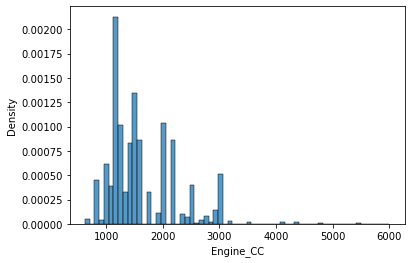

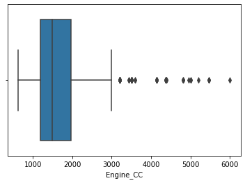

```python
sns.histplot(data=df,x='Engine_CC',stat='density')
plt.show()
sns.boxplot(data=df,x='Engine_CC')
plt.show()
```

- From the distribution, we can see that most of the data is between 1000-3000 with figures after 3000 acting as outliers.
- The boxplot aslo gives us this same insights.

```python
df.head()
```

|  | Name | Location | Year | Kilometers_Driven | Fuel_Type | Transmission | Owner_Type | Mileage | Seats | New_Price | Price | Engine_CC | Power_num |
| --- | --- | --- | --- | --- | --- | --- | --- | --- | --- | --- | --- | --- | --- |
| 0 | Maruti Wagon R LXI CNG | Mumbai | 2010 | 72000 | CNG | Manual | First | 37.24 | 5.0 | 5.51 | 1.75 | 998.0 | 58.16 |
| 1 | Hyundai Creta 1.6 CRDi SX Option | Pune | 2015 | 41000 | Diesel | Manual | First | 19.60 | 5.0 | 16.06 | 12.50 | 1582.0 | 126.20 |
| 2 | Honda Jazz V | Chennai | 2011 | 46000 | Petrol | Manual | First | 18.00 | 5.0 | 8.61 | 4.50 | 1199.0 | 88.70 |
| 3 | Maruti Ertiga VDI | Chennai | 2012 | 87000 | Diesel | Manual | First | 20.70 | 7.0 | 11.27 | 6.00 | 1248.0 | 88.76 |
| 4 | Audi A4 New 2.0 TDI Multitronic | Coimbatore | 2013 | 40670 | Diesel | Automatic | Second | 15.00 | 5.0 | 53.14 | 17.74 | 1968.0 | 140.80 |

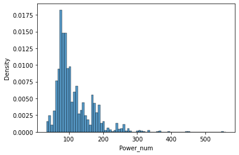

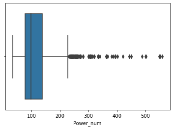

```python
sns.histplot(data=df,x='Power_num',stat='density')
plt.show()
sns.boxplot(data=df,x='Power_num')
plt.show()
```

- The data above is also right skewed and has a lot of outliers.

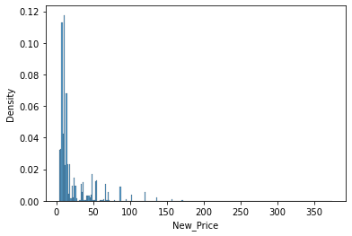

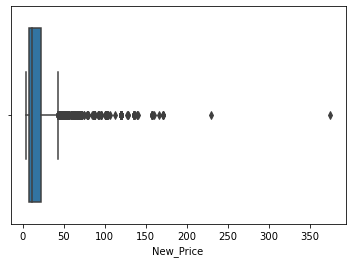

```python
sns.histplot(data=df,x='New_Price',stat='density')
plt.show()
sns.boxplot(data=df,x='New_Price')
plt.show()
```

- The plot above shows us that the data is heavily right-skewed
- From the box plot the data is also right skewed and there are a lot of outliers.

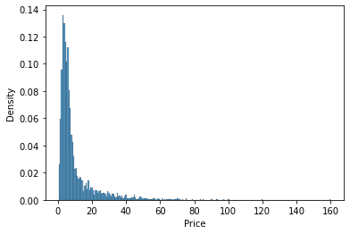

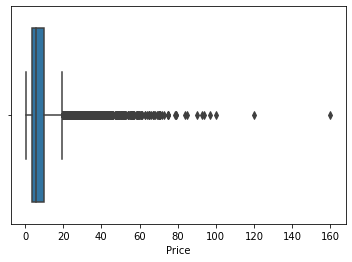

```python
sns.histplot(data=df,x='Price',stat='density')
plt.show()
sns.boxplot(data=df,x='Price')
plt.show()
```

- Our Target Variable is also heavily right skewed.
- Since it is our Target Variable, it is best not to do any transformations on them.

#### Let's check the distribution for categorical columns.

```python
# function to create labeled barplots


def labeled_barplot(data, feature, perc=False, n=None):
    """
    Barplot with percentage at the top

    data: dataframe
    feature: dataframe column
    perc: whether to display percentages instead of count (default is False)
    n: displays the top n category levels (default is None, i.e., display all levels)
    """

    total = len(data[feature])  # length of the column
    count = data[feature].nunique()
    if n is None:
        plt.figure(figsize=(count + 1, 5))
    else:
        plt.figure(figsize=(n + 1, 5))

    plt.xticks(rotation=90, fontsize=15)
    ax = sns.countplot(
        data=data,
        x=feature,
        palette="Paired",
        order=data[feature].value_counts().index[:n].sort_values(),
    )

    for p in ax.patches:
        if perc == True:
            label = "{:.1f}%".format(
                100 * p.get_height() / total
            )  # percentage of each class of the category
        else:
            label = p.get_height()  # count of each level of the category

        x = p.get_x() + p.get_width() / 2  # width of the plot
        y = p.get_height()  # height of the plot

        ax.annotate(
            label,
            (x, y),
            ha="center",
            va="center",
            size=12,
            xytext=(0, 5),
            textcoords="offset points",
        )  # annotate the percentage

    plt.show()  # show the plot
```

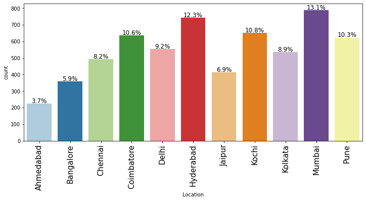

```python
labeled_barplot(df, "Location", perc=True)
```

- There are 11 different unique locations from our data and they have all been plotted
- Mumbai is the Location with highest number of cars available for purchase or has the highest number of sales
- Ahmedabad has the lowest record of cars available or purchases

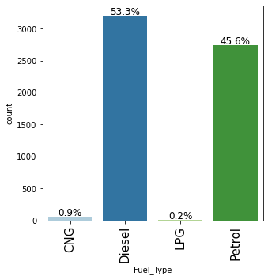

```python
labeled_barplot(df, "Fuel_Type", perc=True)
```

- Most cars use Diesel and Petrol as their fuel type

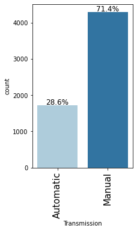

```python
labeled_barplot(df, "Transmission", perc=True)
```

- Most cars use the Manual Transmission

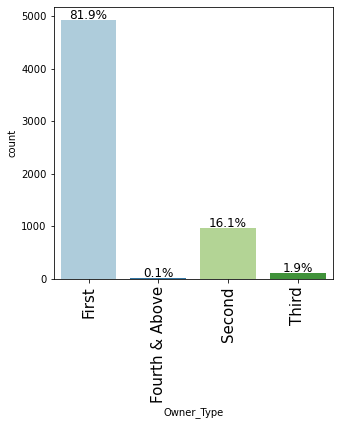

```python
labeled_barplot(df, "Owner_Type", perc=True)
```

- Most of the owners are in the category of first.

```python
df.Name.nunique()
```

```
1874
```

#### Dropping the Name Column

```python
df.drop(['Name'], axis=1, inplace=True)
```

```python
df.head()
```

|  | Location | Year | Kilometers_Driven | Fuel_Type | Transmission | Owner_Type | Mileage | Seats | New_Price | Price | Engine_CC | Power_num |
| --- | --- | --- | --- | --- | --- | --- | --- | --- | --- | --- | --- | --- |
| 0 | Mumbai | 2010 | 72000 | CNG | Manual | First | 37.24 | 5.0 | 5.51 | 1.75 | 998.0 | 58.16 |
| 1 | Pune | 2015 | 41000 | Diesel | Manual | First | 19.60 | 5.0 | 16.06 | 12.50 | 1582.0 | 126.20 |
| 2 | Chennai | 2011 | 46000 | Petrol | Manual | First | 18.00 | 5.0 | 8.61 | 4.50 | 1199.0 | 88.70 |
| 3 | Chennai | 2012 | 87000 | Diesel | Manual | First | 20.70 | 7.0 | 11.27 | 6.00 | 1248.0 | 88.76 |
| 4 | Coimbatore | 2013 | 40670 | Diesel | Automatic | Second | 15.00 | 5.0 | 53.14 | 17.74 | 1968.0 | 140.80 |

- We Successfully dropped the Name Column.

### Bivariate Analysis

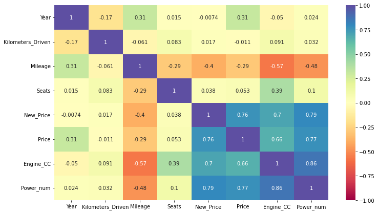

```python
plt.figure(figsize=(12,7))
sns.heatmap(df.corr(),annot=True,cmap='Spectral',vmin=-1,vmax=1)
plt.show()
```

```python
df.head()
```

|  | Location | Year | Kilometers_Driven | Fuel_Type | Transmission | Owner_Type | Mileage | Seats | New_Price | Price | Engine_CC | Power_num |
| --- | --- | --- | --- | --- | --- | --- | --- | --- | --- | --- | --- | --- |
| 0 | Mumbai | 2010 | 72000 | CNG | Manual | First | 37.24 | 5.0 | 5.51 | 1.75 | 998.0 | 58.16 |
| 1 | Pune | 2015 | 41000 | Diesel | Manual | First | 19.60 | 5.0 | 16.06 | 12.50 | 1582.0 | 126.20 |
| 2 | Chennai | 2011 | 46000 | Petrol | Manual | First | 18.00 | 5.0 | 8.61 | 4.50 | 1199.0 | 88.70 |
| 3 | Chennai | 2012 | 87000 | Diesel | Manual | First | 20.70 | 7.0 | 11.27 | 6.00 | 1248.0 | 88.76 |
| 4 | Coimbatore | 2013 | 40670 | Diesel | Automatic | Second | 15.00 | 5.0 | 53.14 | 17.74 | 1968.0 | 140.80 |

#### LOCATION VS PRICE

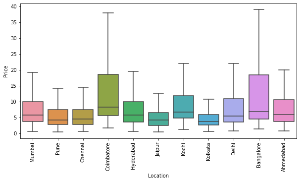

```python
plt.figure(figsize=(10,5))
sns.boxplot(data=df,x='Location',y='Price',showfliers=False) # turning off outliers
plt.xticks(rotation=90)
plt.show()
```

#### YEAR VS PRICE

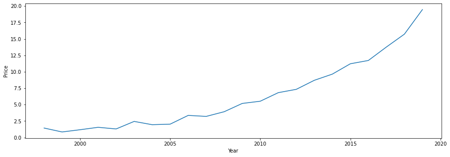

```python
plt.figure(figsize=(15,5))
sns.lineplot(data=df,x='Year',y='Price',ci=None)
plt.show()
```

- The Year a car was Purchased affects the price too
- Cars manufactured in recent times tend to have a higher price than cars manufactured way before 2010

#### FUEL TYPE VS PRICE

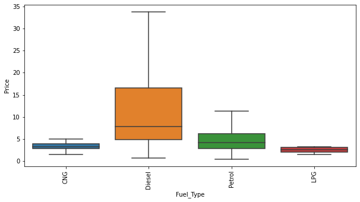

```python
plt.figure(figsize=(10,5))
sns.boxplot(data=df,x='Fuel_Type',y='Price',showfliers=False) # turning off outliers
plt.xticks(rotation=90)
plt.show()
```

- Cars with Diesel as its Fuel type tend to have higher prices than that of Petrol,lpg and Cng

#### TRANSMISSION VS PRICE

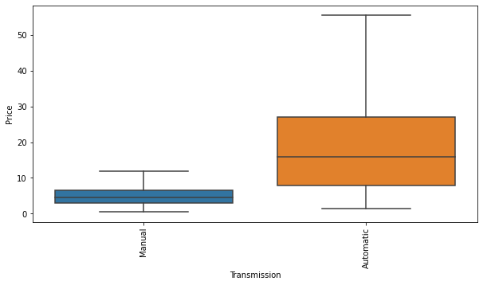

```python
plt.figure(figsize=(10,5))
sns.boxplot(data=df,x='Transmission',y='Price',showfliers=False) # turning off outliers
plt.xticks(rotation=90)
plt.show()
```

- In our Univariate analysis it was noticed that There are More Manual cars being sold than Automatic.
- But with Our Bivariate it is seen that Autonatic cars generally have higher prices than Manual cars
- So the reason why Manual cars are sold more is because they are cheaper than Automatic cars

#### SEATS VS PRICE

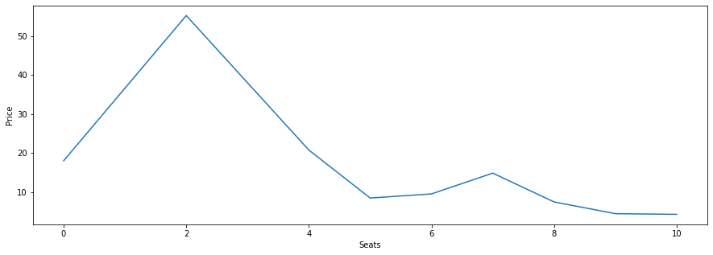

```python
plt.figure(figsize=(15,5))
sns.lineplot(data=df,x='Seats',y='Price',ci=None)
plt.show()
```

- From this Bivariate analysis, we can notice that cars with lower seats tend to have a higher price.
- From this analysis we can tell that cars with lower seats could be sports cars or luxury cars that shows why they have higher prices than cars with more seats which are buses in general.

#### ENGINE VS PRICE

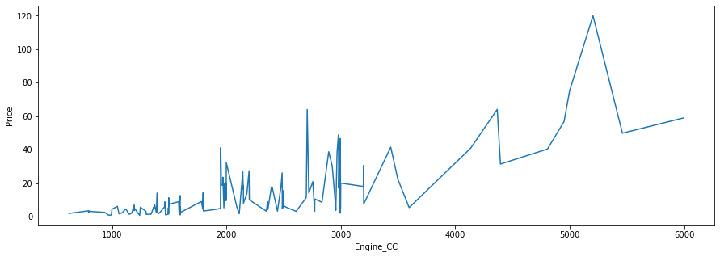

```python
plt.figure(figsize=(15,5))
sns.lineplot(data=df,x='Engine_CC',y='Price',ci=None)
plt.show()
```

- The Engine volume directly influences the Price
- The Higher the Engine volume the higher the price

#### POWER VS PRICE

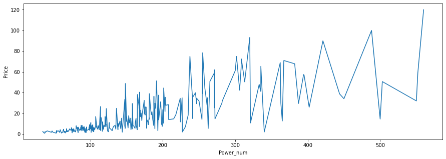

```python
plt.figure(figsize=(15,5))
sns.lineplot(data=df,x='Power_num',y='Price',ci=None)
plt.show()
```

#### YEAR VS POWER

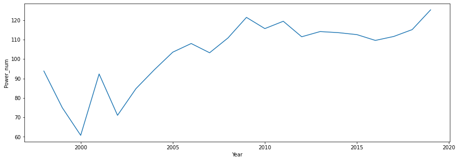

```python
plt.figure(figsize=(15,5))
sns.lineplot(data=df,x='Year',y='Power_num',ci=None)
plt.show()
```

- The year a car was manufactured also affects the power.
- This makes sense why the higher the power is the higher the price is and why cars manufactured in recent times cost more.

```python
df.head()
```

|  | Location | Year | Kilometers_Driven | Fuel_Type | Transmission | Owner_Type | Mileage | Seats | New_Price | Price | Engine_CC | Power_num |
| --- | --- | --- | --- | --- | --- | --- | --- | --- | --- | --- | --- | --- |
| 0 | Mumbai | 2010 | 72000 | CNG | Manual | First | 37.24 | 5.0 | 5.51 | 1.75 | 998.0 | 58.16 |
| 1 | Pune | 2015 | 41000 | Diesel | Manual | First | 19.60 | 5.0 | 16.06 | 12.50 | 1582.0 | 126.20 |
| 2 | Chennai | 2011 | 46000 | Petrol | Manual | First | 18.00 | 5.0 | 8.61 | 4.50 | 1199.0 | 88.70 |
| 3 | Chennai | 2012 | 87000 | Diesel | Manual | First | 20.70 | 7.0 | 11.27 | 6.00 | 1248.0 | 88.76 |
| 4 | Coimbatore | 2013 | 40670 | Diesel | Automatic | Second | 15.00 | 5.0 | 53.14 | 17.74 | 1968.0 | 140.80 |

### VARIABLE TRANSFORMATIONS AND OUTLIERS

```python
# creating a copy of the dataframe
df2 = df.copy()
```

#### LOG TRANSFORMATION

- Some features are very skewed and will likely behave better on the log scale.These are Kilometers driven and New price

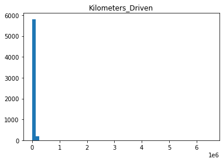

```
0
```

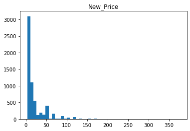

```
0
```

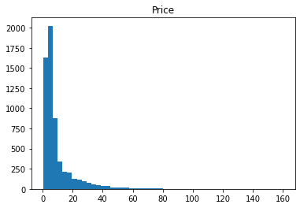

```
0
```

```python
# Defining columns we want to take the log transformation on
cols_to_log = ['Kilometers_Driven', 'New_Price','Price']
for colname in cols_to_log:
    plt.hist(df2[colname], bins=50)
    plt.title(colname)
    plt.show()
    print(np.sum(df[colname] <= 0))
```

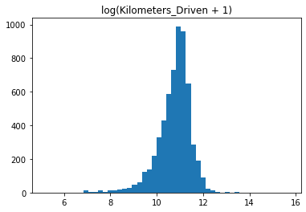

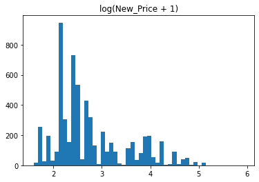

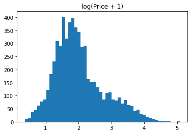

```python
# Plotting Graph to show columns after log was applied
plt.hist(np.log(df2['Kilometers_Driven'] + 1), 50)
plt.title('log(Kilometers_Driven + 1)')
plt.show()
plt.hist(np.log(df2['New_Price'] + 1), 50)
plt.title('log(New_Price + 1)')
plt.show()
plt.hist(np.log(df2['Price'] + 1), 50)
plt.title('log(Price + 1)')
plt.show()
```

```python
for colname in cols_to_log:
    df2[colname + '_log'] = np.log(df2[colname] + 1)
df2.drop(cols_to_log, axis=1, inplace=True)
```

```python
df2.head()
```

|  | Location | Year | Fuel_Type | Transmission | Owner_Type | Mileage | Seats | Engine_CC | Power_num | Kilometers_Driven_log | New_Price_log | Price_log |
| --- | --- | --- | --- | --- | --- | --- | --- | --- | --- | --- | --- | --- |
| 0 | Mumbai | 2010 | CNG | Manual | First | 37.24 | 5.0 | 998.0 | 58.16 | 11.184435 | 1.873339 | 1.011601 |
| 1 | Pune | 2015 | Diesel | Manual | First | 19.60 | 5.0 | 1582.0 | 126.20 | 10.621352 | 2.836737 | 2.602690 |
| 2 | Chennai | 2011 | Petrol | Manual | First | 18.00 | 5.0 | 1199.0 | 88.70 | 10.736418 | 2.262804 | 1.704748 |
| 3 | Chennai | 2012 | Diesel | Manual | First | 20.70 | 7.0 | 1248.0 | 88.76 | 11.373675 | 2.507157 | 1.945910 |
| 4 | Coimbatore | 2013 | Diesel | Automatic | Second | 15.00 | 5.0 | 1968.0 | 140.80 | 10.613271 | 3.991573 | 2.930660 |

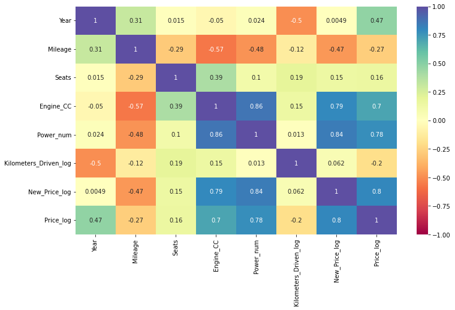

```python
plt.figure(figsize=(12,7))
sns.heatmap(df2.corr(),annot=True,cmap='Spectral',vmin=-1,vmax=1)
plt.show()
```

- After applying the log, we notice that some relationships between variables have increased.
- For example the year and the price has increased which is a good thing.
- So the log transformation affected our data positively

#### HANDLING OUTLIERS

- An outlier is a data point that are abnormally/unrealistically distant from other points in the data.
- The challenge with outlier detection is determining if a point is truly a problem or simply a large value. If a point is genuine then it is very important to keep it in the data as otherwise we're removing the most interesting data points.

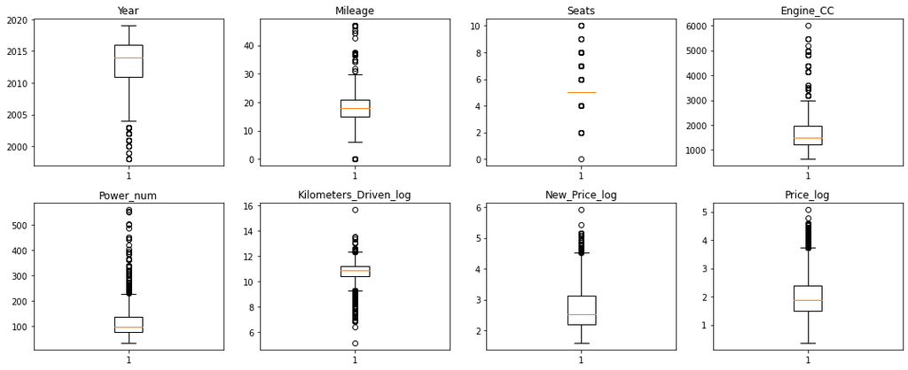

```python
num_columns = ['Year', 'Mileage', 'Seats', 'Engine_CC', 'Power_num', 'Kilometers_Driven_log','New_Price_log','Price_log']
plt.figure(figsize=(15, 12))

for i, variable in enumerate(num_columns):
    plt.subplot(4, 4, i + 1)
    plt.boxplot(df2[variable], whis=1.5)
    plt.tight_layout()
    plt.title(variable)

plt.show()
```

```python
df2[df2['Mileage']>30]
```

|  | Location | Year | Fuel_Type | Transmission | Owner_Type | Mileage | Seats | Engine_CC | Power_num | Kilometers_Driven_log | New_Price_log | Price_log |
| --- | --- | --- | --- | --- | --- | --- | --- | --- | --- | --- | --- | --- |
| 0 | Mumbai | 2010 | CNG | Manual | First | 37.240 | 5.0 | 998.0 | 58.16 | 11.184435 | 1.873339 | 1.011601 |
| 127 | Pune | 2013 | CNG | Manual | First | 37.240 | 5.0 | 998.0 | 58.16 | 11.406464 | 1.873339 | 1.446919 |
| 328 | Pune | 2008 | CNG | Manual | First | 36.820 | 5.0 | 998.0 | 67.10 | 10.657189 | 2.183802 | 0.875469 |
| 839 | Delhi | 2012 | CNG | Manual | First | 37.562 | 5.0 | 796.0 | 38.40 | 11.090385 | 1.678964 | 1.131402 |
| 936 | Hyderabad | 2012 | LPG | Manual | First | 36.680 | 5.0 | 998.0 | 58.20 | 11.184435 | 1.873339 | 1.348073 |
| 1135 | Ahmedabad | 2011 | CNG | Manual | First | 36.820 | 5.0 | 998.0 | 67.10 | 11.238502 | 2.183802 | 1.098612 |
| 1218 | Pune | 2015 | CNG | Manual | First | 36.680 | 5.0 | 998.0 | 58.20 | 11.156265 | 1.873339 | 1.536867 |
| 1269 | Mumbai | 2018 | CNG | Manual | First | 46.816 | 4.0 | 796.0 | 40.30 | 9.268704 | 1.678964 | 1.504077 |
| 1332 | Pune | 2013 | CNG | Manual | First | 46.956 | 5.0 | 998.0 | 67.04 | 11.283449 | 1.877937 | 1.376244 |
| 1357 | Mumbai | 2014 | CNG | Manual | Second | 37.240 | 5.0 | 998.0 | 58.16 | 10.596660 | 1.873339 | 1.423108 |
| 1780 | Mumbai | 2013 | CNG | Manual | First | 37.240 | 5.0 | 998.0 | 58.16 | 10.156423 | 1.873339 | 1.423108 |
| 1911 | Ahmedabad | 2016 | CNG | Manual | First | 37.240 | 5.0 | 998.0 | 58.16 | 11.251574 | 1.873339 | 1.458615 |
| 1914 | Chennai | 2017 | CNG | Manual | First | 35.000 | 5.0 | 1197.0 | 81.86 | 10.736418 | 2.222459 | 1.783391 |
| 2059 | Mumbai | 2013 | CNG | Manual | First | 46.956 | 5.0 | 998.0 | 67.04 | 10.896758 | 1.884035 | 1.398717 |
| 2110 | Pune | 2014 | CNG | Manual | First | 34.440 | 5.0 | 1193.0 | 55.23 | 10.621352 | 2.155245 | 1.446919 |
| 2323 | Delhi | 2016 | CNG | Manual | First | 35.000 | 5.0 | 1197.0 | 81.86 | 10.509905 | 2.222459 | 1.791759 |
| 2371 | Pune | 2014 | CNG | Manual | First | 46.956 | 5.0 | 998.0 | 67.04 | 10.282027 | 1.877937 | 1.589235 |
| 2376 | Hyderabad | 2013 | CNG | Manual | Second | 37.240 | 5.0 | 998.0 | 58.16 | 11.337095 | 1.873339 | 1.373716 |
| 2437 | Chennai | 2015 | CNG | Manual | First | 34.440 | 5.0 | 1193.0 | 55.23 | 11.225257 | 2.155245 | 1.446919 |
| 2516 | Mumbai | 2014 | CNG | Manual | First | 30.940 | 5.0 | 1586.0 | 85.70 | 10.878066 | 2.183802 | 1.449269 |
| 2638 | Pune | 2012 | CNG | Manual | First | 36.680 | 5.0 | 998.0 | 58.20 | 11.412011 | 1.873339 | 1.360977 |
| 2701 | Kochi | 2016 | CNG | Manual | First | 44.506 | 5.0 | 998.0 | 58.33 | 11.163893 | 1.927164 | 1.719189 |
| 3008 | Delhi | 2014 | CNG | Manual | Second | 37.240 | 5.0 | 998.0 | 58.16 | 10.789340 | 1.873339 | 1.348073 |
| 3031 | Mumbai | 2013 | CNG | Manual | First | 31.920 | 7.0 | 1373.0 | 80.90 | 10.878066 | 2.507157 | 1.916923 |
| 3097 | Pune | 2012 | CNG | Manual | Second | 36.680 | 5.0 | 998.0 | 58.20 | 11.429555 | 1.873339 | 1.386294 |
| 3119 | Kochi | 2018 | CNG | Manual | First | 45.164 | 4.0 | 998.0 | 58.20 | 10.696548 | 1.733424 | 1.609438 |
| 3129 | Delhi | 2014 | CNG | Manual | First | 46.956 | 5.0 | 998.0 | 67.04 | 11.220753 | 1.848455 | 1.446919 |
| 3295 | Delhi | 2013 | CNG | Manual | First | 37.240 | 5.0 | 998.0 | 58.16 | 11.034906 | 1.873339 | 1.335001 |
| 3455 | Mumbai | 2014 | CNG | Manual | First | 36.680 | 5.0 | 998.0 | 58.20 | 10.621352 | 1.873339 | 1.504077 |
| 3511 | Hyderabad | 2012 | CNG | Manual | Second | 37.562 | 5.0 | 796.0 | 38.40 | 11.429555 | 1.678964 | 1.131402 |
| 3553 | Pune | 2015 | CNG | Manual | First | 46.816 | 4.0 | 796.0 | 40.30 | 9.798183 | 1.678964 | 1.386294 |
| 3722 | Kochi | 2015 | CNG | Manual | First | 30.940 | 5.0 | 1586.0 | 85.70 | 11.018646 | 2.183802 | 1.587192 |
| 3869 | Delhi | 2012 | CNG | Manual | Second | 46.816 | 4.0 | 796.0 | 40.30 | 11.090385 | 1.678964 | 1.131402 |
| 4141 | Mumbai | 2014 | CNG | Manual | First | 46.956 | 5.0 | 998.0 | 67.04 | 10.762170 | 1.884035 | 1.348073 |
| 4411 | Kochi | 2014 | CNG | Manual | First | 37.240 | 5.0 | 998.0 | 58.16 | 11.132631 | 1.873339 | 1.562346 |
| 4768 | Kochi | 2017 | CNG | Manual | First | 46.816 | 4.0 | 796.0 | 40.30 | 10.098684 | 1.678964 | 1.547563 |
| 4918 | Pune | 2014 | CNG | Manual | First | 37.240 | 5.0 | 998.0 | 58.16 | 10.968216 | 1.873339 | 1.386294 |
| 5176 | Delhi | 2015 | CNG | Manual | First | 44.506 | 5.0 | 998.0 | 58.33 | 11.077331 | 1.927164 | 1.568616 |
| 5504 | Hyderabad | 2012 | LPG | Manual | First | 36.680 | 5.0 | 998.0 | 58.20 | 11.189823 | 1.873339 | 1.435085 |
| 5653 | Mumbai | 2015 | CNG | Manual | First | 37.240 | 5.0 | 998.0 | 58.16 | 9.998889 | 1.873339 | 1.536867 |
| 5708 | Mumbai | 2013 | CNG | Manual | First | 42.644 | 5.0 | 796.0 | 47.30 | 10.173553 | 1.678964 | 1.147402 |
| 5745 | Delhi | 2014 | CNG | Manual | First | 37.240 | 5.0 | 998.0 | 58.16 | 11.043722 | 1.873339 | 1.373716 |
| 5879 | Pune | 2015 | CNG | Manual | First | 37.240 | 5.0 | 998.0 | 58.16 | 10.915107 | 1.873339 | 1.547563 |
| 5900 | Mumbai | 2012 | CNG | Manual | First | 36.680 | 5.0 | 998.0 | 58.20 | 11.184435 | 1.873339 | 1.178655 |
| 5933 | Pune | 2015 | CNG | Manual | Second | 45.164 | 4.0 | 998.0 | 58.20 | 10.994168 | 1.678964 | 1.410987 |
| 5995 | Jaipur | 2010 | LPG | Manual | First | 36.680 | 5.0 | 998.0 | 58.20 | 11.156265 | 1.873339 | 1.184790 |

```python
df2[df2['Mileage']<9]
```

|  | Location | Year | Fuel_Type | Transmission | Owner_Type | Mileage | Seats | Engine_CC | Power_num | Kilometers_Driven_log | New_Price_log | Price_log |
| --- | --- | --- | --- | --- | --- | --- | --- | --- | --- | --- | --- | --- |
| 14 | Pune | 2012 | Diesel | Automatic | Second | 0.0 | 5.0 | 2179.0 | 115.00 | 11.350418 | 4.795791 | 2.917771 |
| 67 | Coimbatore | 2019 | Diesel | Automatic | First | 0.0 | 5.0 | 1950.0 | 194.00 | 9.640173 | 3.914819 | 3.601959 |
| 70 | Mumbai | 2008 | Petrol | Automatic | First | 8.0 | 5.0 | 4806.0 | 500.00 | 11.198228 | 4.919981 | 2.740840 |
| 79 | Hyderabad | 2005 | Petrol | Manual | First | 0.0 | 5.0 | 1086.0 | 97.70 | 11.380445 | 1.713798 | 0.832909 |
| 152 | Kolkata | 2010 | Petrol | Automatic | First | 7.8 | 5.0 | 5461.0 | 362.90 | 10.471015 | 3.921775 | 3.433987 |
| ... | ... | ... | ... | ... | ... | ... | ... | ... | ... | ... | ... | ... |
| 5873 | Ahmedabad | 2019 | Diesel | Automatic | First | 0.0 | 5.0 | 1950.0 | 194.00 | 8.294300 | 3.914819 | 3.583519 |
| 5941 | Chennai | 2002 | Diesel | Manual | First | 0.0 | 6.0 | 2112.0 | 97.70 | 11.225257 | 2.988959 | 0.993252 |
| 5970 | Mumbai | 2008 | Petrol | Manual | Second | 0.0 | 5.0 | 1086.0 | 62.00 | 11.082158 | 1.713798 | 0.871293 |
| 6004 | Mumbai | 2009 | Diesel | Automatic | First | 8.0 | 5.0 | 2987.0 | 224.34 | 11.532758 | 3.921775 | 2.463853 |
| 6009 | Hyderabad | 2009 | Petrol | Automatic | First | 0.0 | 5.0 | 3597.0 | 262.60 | 10.878066 | 3.536893 | 1.749200 |

86 rows × 12 columns

```python
Seats_out =df2[df2['Seats']>5]
```

```python
Seats_out.head(30)
```

|  | Location | Year | Fuel_Type | Transmission | Owner_Type | Mileage | Seats | Engine_CC | Power_num | Kilometers_Driven_log | New_Price_log | Price_log |
| --- | --- | --- | --- | --- | --- | --- | --- | --- | --- | --- | --- | --- |
| 3 | Chennai | 2012 | Diesel | Manual | First | 20.7 | 7.0 | 1248.0 | 88.76 | 11.373675 | 2.507157 | 1.945910 |
| 7 | Mumbai | 2016 | Diesel | Automatic | First | 11.3 | 8.0 | 2755.0 | 171.50 | 10.491302 | 3.091042 | 2.917771 |
| 15 | Delhi | 2014 | Diesel | Manual | First | 13.0 | 7.0 | 2477.0 | 175.56 | 11.608245 | 3.496811 | 2.772589 |
| 29 | Mumbai | 2007 | Diesel | Manual | Fourth & Above | 12.0 | 7.0 | 2494.0 | 102.00 | 12.476104 | 3.219276 | 1.609438 |
| 32 | Bangalore | 2013 | Diesel | Automatic | Second | 11.1 | 7.0 | 2696.0 | 184.00 | 11.184435 | 2.988959 | 2.602690 |
| 42 | Coimbatore | 2017 | Diesel | Manual | First | 25.3 | 6.0 | 1198.0 | 77.00 | 10.000342 | 2.183802 | 1.884035 |
| 47 | Bangalore | 2012 | Petrol | Manual | First | 11.2 | 7.0 | 2694.0 | 163.70 | 11.166272 | 2.977568 | 2.480731 |
| 49 | Jaipur | 2012 | Diesel | Manual | Second | 16.5 | 6.0 | 2498.0 | 105.00 | 11.235867 | 2.516890 | 1.871802 |
| 60 | Mumbai | 2017 | Diesel | Manual | First | 13.6 | 8.0 | 2393.0 | 147.80 | 9.998843 | 3.012589 | 2.862201 |
| 68 | Pune | 2016 | Diesel | Manual | First | 24.5 | 7.0 | 1248.0 | 88.50 | 11.050906 | 2.507157 | 2.213754 |
| 71 | Mumbai | 2015 | Diesel | Manual | First | 15.0 | 7.0 | 2179.0 | 140.00 | 10.928274 | 2.988959 | 2.365560 |
| 77 | Chennai | 2006 | Petrol | Manual | Third | 12.0 | 8.0 | 1998.0 | 132.00 | 12.345839 | 3.219276 | 1.704748 |
| 78 | Hyderabad | 2012 | Diesel | Manual | First | 12.0 | 7.0 | 2494.0 | 102.00 | 11.552156 | 3.219276 | 2.545531 |
| 91 | Delhi | 2014 | Diesel | Manual | First | 13.0 | 7.0 | 2982.0 | 168.50 | 11.580593 | 3.642050 | 2.862201 |
| 94 | Delhi | 2014 | Diesel | Manual | First | 15.0 | 7.0 | 2179.0 | 140.00 | 10.968216 | 2.988959 | 2.208274 |
| 102 | Pune | 2017 | Petrol | Manual | First | 19.8 | 7.0 | 1198.0 | 67.00 | 10.399768 | 2.008214 | 1.599388 |
| 108 | Delhi | 2012 | Diesel | Manual | Second | 16.0 | 7.0 | 2179.0 | 140.00 | 11.082158 | 2.988959 | 1.909543 |
| 110 | Mumbai | 2017 | Diesel | Automatic | First | 11.3 | 7.0 | 2755.0 | 171.50 | 10.308986 | 3.332205 | 3.008155 |
| 115 | Ahmedabad | 2014 | Diesel | Manual | First | 12.9 | 7.0 | 2494.0 | 100.60 | 10.915107 | 3.219276 | 2.494032 |
| 125 | Kolkata | 2014 | Diesel | Manual | First | 12.0 | 8.0 | 2179.0 | 120.00 | 10.645449 | 2.988959 | 2.169054 |
| 131 | Jaipur | 2016 | Diesel | Automatic | First | 16.0 | 7.0 | 2179.0 | 140.00 | 10.896758 | 2.988959 | 2.656757 |
| 144 | Coimbatore | 2012 | Diesel | Manual | First | 11.0 | 7.0 | 2982.0 | 171.00 | 11.421205 | 3.642050 | 2.673459 |
| 161 | Ahmedabad | 2016 | Diesel | Manual | First | 12.9 | 7.0 | 2494.0 | 100.60 | 11.407576 | 3.219276 | 2.476538 |
| 163 | Mumbai | 2012 | Diesel | Manual | First | 15.0 | 7.0 | 2179.0 | 140.00 | 10.397970 | 2.988959 | 2.186051 |
| 165 | Mumbai | 2012 | Diesel | Manual | First | 13.0 | 7.0 | 2982.0 | 168.50 | 11.788783 | 3.642050 | 2.674149 |
| 185 | Mumbai | 2015 | Diesel | Manual | First | 19.9 | 8.0 | 1461.0 | 108.50 | 10.126671 | 2.775709 | 2.047693 |
| 190 | Kochi | 2016 | Diesel | Manual | First | 15.0 | 7.0 | 1997.0 | 120.00 | 10.946235 | 2.988959 | 2.425687 |
| 193 | Mumbai | 2016 | Diesel | Manual | First | 25.4 | 7.0 | 1248.0 | 88.50 | 10.404293 | 2.620311 | 2.251292 |
| 200 | Chennai | 2017 | Diesel | Manual | Second | 17.4 | 7.0 | 1493.0 | 100.00 | 10.275086 | 2.444085 | 2.014903 |
| 235 | Kochi | 2019 | Diesel | Automatic | First | 11.3 | 7.0 | 2755.0 | 171.50 | 9.558600 | 3.079154 | 3.027231 |

```python
df2[df2['Seats']==10]
```

|  | Location | Year | Fuel_Type | Transmission | Owner_Type | Mileage | Seats | Engine_CC | Power_num | Kilometers_Driven_log | New_Price_log | Price_log |
| --- | --- | --- | --- | --- | --- | --- | --- | --- | --- | --- | --- | --- |
| 814 | Pune | 2004 | Diesel | Manual | Second | 13.0 | 10.0 | 2446.0 | 75.0 | 11.261357 | 3.219276 | 1.504077 |
| 917 | Mumbai | 2013 | Diesel | Manual | First | 14.0 | 10.0 | 1978.0 | 83.1 | 9.903538 | 2.155245 | 1.832581 |
| 1907 | Bangalore | 2002 | Diesel | Manual | Third | 13.0 | 10.0 | 2446.0 | 75.0 | 11.050906 | 3.219276 | 1.536867 |
| 2267 | Pune | 2004 | Diesel | Manual | Second | 0.0 | 10.0 | 2446.0 | 97.7 | 12.281880 | 3.219276 | 1.504077 |
| 2575 | Hyderabad | 2015 | Diesel | Manual | First | 14.0 | 10.0 | 2499.0 | 80.0 | 11.695255 | 2.509599 | 1.871802 |

```python
df2[df2['Seats']<2]
```

|  | Location | Year | Fuel_Type | Transmission | Owner_Type | Mileage | Seats | Engine_CC | Power_num | Kilometers_Driven_log | New_Price_log | Price_log |
| --- | --- | --- | --- | --- | --- | --- | --- | --- | --- | --- | --- | --- |
| 3999 | Hyderabad | 2012 | Petrol | Automatic | First | 10.0 | 0.0 | 3197.0 | 97.7 | 11.736077 | 3.991573 | 2.944439 |

```python
engine=df2[df2['Engine_CC']>3000]
```

```python
engine.head(60)
```

|  | Location | Year | Fuel_Type | Transmission | Owner_Type | Mileage | Seats | Engine_CC | Power_num | Kilometers_Driven_log | New_Price_log | Price_log |
| --- | --- | --- | --- | --- | --- | --- | --- | --- | --- | --- | --- | --- |
| 70 | Mumbai | 2008 | Petrol | Automatic | First | 8.0 | 5.0 | 4806.0 | 500.00 | 11.198228 | 4.919981 | 2.740840 |
| 152 | Kolkata | 2010 | Petrol | Automatic | First | 7.8 | 5.0 | 5461.0 | 362.90 | 10.471015 | 3.921775 | 3.433987 |
| 459 | Coimbatore | 2016 | Diesel | Automatic | First | 11.3 | 7.0 | 4134.0 | 335.20 | 10.839640 | 4.634341 | 3.910221 |
| 586 | Kochi | 2014 | Diesel | Automatic | First | 11.3 | 7.0 | 4134.0 | 335.20 | 11.288869 | 4.634341 | 3.426540 |
| 589 | Bangalore | 2006 | Petrol | Automatic | Second | 10.1 | 5.0 | 3498.0 | 364.90 | 10.759795 | 3.921775 | 2.995732 |
| 693 | Coimbatore | 2016 | Petrol | Automatic | First | 18.0 | 2.0 | 3498.0 | 306.00 | 10.031573 | 3.921775 | 4.034948 |
| 703 | Coimbatore | 2017 | Diesel | Automatic | First | 10.9 | 7.0 | 3198.0 | 197.20 | 10.829432 | 3.591542 | 3.469479 |
| 798 | Bangalore | 2015 | Petrol | Automatic | First | 18.0 | 2.0 | 3498.0 | 306.00 | 9.210440 | 3.921775 | 4.025352 |
| 806 | Coimbatore | 2017 | Diesel | Automatic | First | 10.9 | 7.0 | 3198.0 | 197.00 | 10.996031 | 3.591542 | 3.407842 |
| 926 | Hyderabad | 2010 | Petrol | Manual | First | 9.0 | 2.0 | 3436.0 | 97.70 | 9.210440 | 4.919981 | 3.713572 |
| 1038 | Bangalore | 2011 | Diesel | Automatic | First | 10.0 | 7.0 | 4367.0 | 308.00 | 10.915107 | 4.795791 | 4.219508 |
| 1076 | Hyderabad | 2016 | Diesel | Automatic | First | 10.9 | 7.0 | 3198.0 | 197.00 | 11.127278 | 3.591542 | 3.417727 |
| 1093 | Bangalore | 2014 | Diesel | Automatic | First | 11.3 | 7.0 | 4134.0 | 335.20 | 10.819798 | 4.634341 | 3.951244 |
| 1352 | Bangalore | 2012 | Diesel | Automatic | First | 10.0 | 7.0 | 4367.0 | 308.00 | 11.105544 | 4.795791 | 4.262680 |
| 1430 | Kochi | 2018 | Diesel | Automatic | First | 10.9 | 7.0 | 3198.0 | 197.20 | 10.327218 | 3.591542 | 3.509753 |
| 1596 | Delhi | 2008 | Petrol | Automatic | First | 8.0 | 7.0 | 4134.0 | 250.00 | 11.170449 | 4.634341 | 2.564180 |
| 1724 | Delhi | 2017 | Diesel | Automatic | First | 10.9 | 7.0 | 3198.0 | 197.00 | 10.545368 | 3.591542 | 3.449352 |
| 1930 | Mumbai | 2007 | Petrol | Automatic | Third | 10.1 | 5.0 | 3498.0 | 364.90 | 10.915107 | 3.921775 | 2.396986 |
| 2100 | Mumbai | 2010 | Petrol | Automatic | Second | 11.0 | 5.0 | 4806.0 | 550.00 | 10.463132 | 4.919981 | 3.496508 |
| 2305 | Mumbai | 2011 | Petrol | Automatic | First | 9.0 | 2.0 | 3436.0 | 97.70 | 8.987322 | 4.919981 | 3.784190 |
| 2588 | Chennai | 2007 | Diesel | Manual | First | 11.5 | 7.0 | 3200.0 | 199.30 | 12.095325 | 3.532518 | 2.140066 |
| 2669 | Coimbatore | 2018 | Diesel | Automatic | First | 10.9 | 7.0 | 3198.0 | 197.20 | 10.849939 | 3.591542 | 3.442659 |
| 2681 | Hyderabad | 2010 | Petrol | Automatic | First | 0.0 | 5.0 | 3597.0 | 262.60 | 10.896758 | 3.536893 | 1.945910 |
| 2978 | Coimbatore | 2010 | Petrol | Automatic | Third | 8.0 | 4.0 | 4806.0 | 394.30 | 10.654927 | 4.919981 | 3.782142 |
| 3028 | Coimbatore | 2017 | Diesel | Automatic | First | 10.9 | 7.0 | 3198.0 | 197.00 | 11.020414 | 3.591542 | 3.397189 |
| 3065 | Mumbai | 2010 | Petrol | Automatic | First | 10.9 | 5.0 | 3498.0 | 272.00 | 11.198228 | 4.476996 | 2.433613 |
| 3079 | Mumbai | 2016 | Diesel | Automatic | First | 10.9 | 7.0 | 3198.0 | 197.00 | 10.275086 | 3.591542 | 3.427515 |
| 3115 | Jaipur | 2016 | Diesel | Automatic | First | 10.9 | 7.0 | 3198.0 | 197.20 | 11.407576 | 3.591542 | 3.295837 |
| 3196 | Chennai | 2019 | Diesel | Automatic | First | 10.9 | 7.0 | 3198.0 | 197.00 | 9.105091 | 3.591542 | 3.597312 |
| 3242 | Bangalore | 2012 | Diesel | Automatic | Second | 11.4 | 5.0 | 4367.0 | 335.30 | 11.050906 | 4.795791 | 4.189655 |
| 3341 | Kochi | 2010 | Petrol | Automatic | First | 8.7 | 5.0 | 4395.0 | 402.00 | 10.823013 | 5.068904 | 3.293241 |
| 3580 | Hyderabad | 2010 | Diesel | Automatic | First | 9.0 | 4.0 | 3498.0 | 271.72 | 10.275086 | 3.921775 | 3.496508 |
| 3999 | Hyderabad | 2012 | Petrol | Automatic | First | 10.0 | 0.0 | 3197.0 | 97.70 | 11.736077 | 3.991573 | 2.944439 |
| 4039 | Mumbai | 2011 | Petrol | Automatic | Second | 11.0 | 7.0 | 3498.0 | 272.00 | 11.314487 | 3.921775 | 2.882004 |
| 4136 | Mumbai | 2009 | Petrol | Automatic | Second | 10.9 | 5.0 | 3498.0 | 272.00 | 11.127292 | 4.476996 | 2.545531 |
| 4227 | Chennai | 2016 | Diesel | Automatic | First | 10.9 | 7.0 | 3198.0 | 197.20 | 10.668979 | 3.591542 | 3.314186 |
| 4342 | Mumbai | 2006 | Petrol | Automatic | First | 10.1 | 5.0 | 3498.0 | 364.90 | 11.542494 | 3.921775 | 2.287471 |
| 4388 | Bangalore | 2015 | Diesel | Automatic | First | 11.3 | 7.0 | 4134.0 | 335.20 | 10.819798 | 4.634341 | 3.891820 |
| 4450 | Kochi | 2018 | Petrol | Automatic | First | 13.0 | 4.0 | 4951.0 | 395.00 | 9.966040 | 4.441710 | 4.056989 |
| 4558 | Delhi | 2010 | Diesel | Automatic | First | 11.3 | 7.0 | 4134.0 | 335.20 | 11.198228 | 4.634341 | 2.918311 |
| 4626 | Kochi | 2010 | Petrol | Automatic | First | 7.9 | 4.0 | 4395.0 | 450.00 | 11.087207 | 4.026601 | 3.078233 |
| 4690 | Bangalore | 2014 | Petrol | Automatic | Second | 12.0 | 2.0 | 5461.0 | 421.00 | 8.006701 | 3.921775 | 4.510860 |
| 4721 | Kolkata | 2010 | Petrol | Automatic | First | 8.0 | 2.0 | 5461.0 | 387.30 | 10.463132 | 3.921775 | 3.417727 |
| 4820 | Mumbai | 2011 | Petrol | Automatic | First | 7.9 | 4.0 | 4395.0 | 450.00 | 8.682877 | 4.026601 | 3.881564 |
| 4868 | Coimbatore | 2012 | Diesel | Automatic | First | 10.0 | 7.0 | 4367.0 | 308.00 | 11.343145 | 4.795791 | 3.980429 |
| 4904 | Hyderabad | 2018 | Diesel | Automatic | First | 10.9 | 7.0 | 3198.0 | 197.00 | 9.615872 | 3.591542 | 3.526361 |
| 4936 | Coimbatore | 2015 | Diesel | Automatic | First | 11.3 | 7.0 | 4134.0 | 335.20 | 10.937366 | 4.634341 | 3.964426 |
| 5086 | Coimbatore | 2011 | Petrol | Automatic | First | 10.0 | 4.0 | 5000.0 | 503.00 | 10.684806 | 4.258092 | 3.944684 |
| 5276 | Delhi | 2018 | Diesel | Automatic | First | 10.9 | 7.0 | 3198.0 | 197.00 | 9.392745 | 3.591542 | 3.540959 |
| 5321 | Chennai | 2017 | Diesel | Automatic | First | 10.9 | 7.0 | 3198.0 | 197.00 | 9.741027 | 3.591542 | 3.465736 |
| 5339 | Coimbatore | 2016 | Diesel | Automatic | First | 13.0 | 5.0 | 4134.0 | 382.00 | 11.082204 | 4.919981 | 4.231640 |
| 5412 | Kochi | 2014 | Petrol | Automatic | First | 11.0 | 7.0 | 3498.0 | 272.00 | 10.730094 | 3.921775 | 3.205993 |
| 5414 | Coimbatore | 2013 | Diesel | Automatic | Second | 11.4 | 5.0 | 4367.0 | 335.30 | 11.238436 | 4.795791 | 4.201853 |
| 5439 | Coimbatore | 2017 | Diesel | Automatic | First | 10.9 | 7.0 | 3198.0 | 197.00 | 10.908723 | 3.591542 | 3.445214 |
| 5519 | Hyderabad | 2006 | Petrol | Automatic | First | 8.0 | 4.0 | 5998.0 | 552.00 | 10.778977 | 5.929589 | 4.094345 |
| 5601 | Delhi | 2013 | Diesel | Automatic | First | 7.0 | 4.0 | 4806.0 | 394.30 | 10.502352 | 4.919981 | 4.290459 |
| 5726 | Kolkata | 2009 | Petrol | Automatic | First | 10.9 | 5.0 | 3498.0 | 272.00 | 10.682835 | 4.476996 | 2.419479 |
| 5779 | Delhi | 2011 | Petrol | Automatic | Third | 6.0 | 2.0 | 5204.0 | 560.00 | 8.779711 | 2.509599 | 4.795791 |
| 5883 | Pune | 2010 | Petrol | Automatic | Second | 11.0 | 7.0 | 3498.0 | 272.00 | 11.440366 | 3.921775 | 2.772589 |
| 5917 | Hyderabad | 2015 | Petrol | Automatic | First | 12.0 | 2.0 | 5000.0 | 488.10 | 8.987322 | 4.258092 | 4.615121 |

```python
df2[df2['Power_num']>300]
```

|  | Location | Year | Fuel_Type | Transmission | Owner_Type | Mileage | Seats | Engine_CC | Power_num | Kilometers_Driven_log | New_Price_log | Price_log |
| --- | --- | --- | --- | --- | --- | --- | --- | --- | --- | --- | --- | --- |
| 70 | Mumbai | 2008 | Petrol | Automatic | First | 8.0 | 5.0 | 4806.0 | 500.00 | 11.198228 | 4.919981 | 2.740840 |
| 134 | Kolkata | 2017 | Petrol | Automatic | First | 19.0 | 2.0 | 2996.0 | 362.07 | 9.500993 | 4.564765 | 4.007333 |
| 148 | Mumbai | 2013 | Petrol | Automatic | First | 11.0 | 4.0 | 2894.0 | 444.00 | 10.043293 | 4.859812 | 3.637586 |
| 152 | Kolkata | 2010 | Petrol | Automatic | First | 7.8 | 5.0 | 5461.0 | 362.90 | 10.471015 | 3.921775 | 3.433987 |
| 326 | Mumbai | 2011 | Diesel | Automatic | First | 9.5 | 4.0 | 2993.0 | 313.00 | 10.308986 | 4.026601 | 3.912023 |
| 418 | Coimbatore | 2018 | Petrol | Automatic | First | 11.0 | 5.0 | 2996.0 | 367.00 | 10.016727 | 4.568299 | 4.276527 |
| 459 | Coimbatore | 2016 | Diesel | Automatic | First | 11.3 | 7.0 | 4134.0 | 335.20 | 10.839640 | 4.634341 | 3.910221 |
| 586 | Kochi | 2014 | Diesel | Automatic | First | 11.3 | 7.0 | 4134.0 | 335.20 | 11.288869 | 4.634341 | 3.426540 |
| 589 | Bangalore | 2006 | Petrol | Automatic | Second | 10.1 | 5.0 | 3498.0 | 364.90 | 10.759795 | 3.921775 | 2.995732 |
| 693 | Coimbatore | 2016 | Petrol | Automatic | First | 18.0 | 2.0 | 3498.0 | 306.00 | 10.031573 | 3.921775 | 4.034948 |
| 798 | Bangalore | 2015 | Petrol | Automatic | First | 18.0 | 2.0 | 3498.0 | 306.00 | 9.210440 | 3.921775 | 4.025352 |
| 1038 | Bangalore | 2011 | Diesel | Automatic | First | 10.0 | 7.0 | 4367.0 | 308.00 | 10.915107 | 4.795791 | 4.219508 |
| 1093 | Bangalore | 2014 | Diesel | Automatic | First | 11.3 | 7.0 | 4134.0 | 335.20 | 10.819798 | 4.634341 | 3.951244 |
| 1123 | Pune | 2008 | Petrol | Automatic | Second | 8.4 | 5.0 | 2979.0 | 321.00 | 11.097425 | 5.068904 | 2.463853 |
| 1352 | Bangalore | 2012 | Diesel | Automatic | First | 10.0 | 7.0 | 4367.0 | 308.00 | 11.105544 | 4.795791 | 4.262680 |
| 1741 | Hyderabad | 2013 | Diesel | Automatic | First | 11.0 | 4.0 | 2993.0 | 306.00 | 10.968216 | 4.026601 | 3.891820 |
| 1930 | Mumbai | 2007 | Petrol | Automatic | Third | 10.1 | 5.0 | 3498.0 | 364.90 | 10.915107 | 3.921775 | 2.396986 |
| 1974 | Coimbatore | 2018 | Petrol | Automatic | First | 12.0 | 5.0 | 2979.0 | 320.00 | 10.242136 | 5.068904 | 4.550397 |
| 1984 | Bangalore | 2017 | Petrol | Automatic | First | 12.0 | 5.0 | 2979.0 | 320.00 | 9.768011 | 5.068904 | 4.543295 |
| 2089 | Mumbai | 2013 | Diesel | Automatic | First | 9.5 | 4.0 | 2993.0 | 313.00 | 10.308986 | 4.026601 | 3.828641 |
| 2095 | Coimbatore | 2019 | Petrol | Automatic | First | 19.0 | 2.0 | 2996.0 | 362.07 | 7.834788 | 4.672829 | 4.442181 |
| 2100 | Mumbai | 2010 | Petrol | Automatic | Second | 11.0 | 5.0 | 4806.0 | 550.00 | 10.463132 | 4.919981 | 3.496508 |
| 2515 | Delhi | 2013 | Diesel | Automatic | Second | 17.5 | 4.0 | 2993.0 | 313.00 | 9.952325 | 4.026601 | 3.806662 |
| 2547 | Chennai | 2016 | Diesel | Automatic | First | 15.8 | 5.0 | 2993.0 | 308.43 | 10.126671 | 4.026601 | 4.110874 |
| 2907 | Hyderabad | 2015 | Diesel | Automatic | First | 14.4 | 5.0 | 2993.0 | 301.73 | 10.165890 | 4.258092 | 4.330733 |
| 2978 | Coimbatore | 2010 | Petrol | Automatic | Third | 8.0 | 4.0 | 4806.0 | 394.30 | 10.654927 | 4.919981 | 3.782142 |
| 3132 | Kochi | 2019 | Petrol | Automatic | First | 13.3 | 5.0 | 2995.0 | 340.00 | 9.567945 | 4.919981 | 1.105257 |
| 3242 | Bangalore | 2012 | Diesel | Automatic | Second | 11.4 | 5.0 | 4367.0 | 335.30 | 11.050906 | 4.795791 | 4.189655 |
| 3266 | Kolkata | 2015 | Petrol | Automatic | First | 10.0 | 4.0 | 2996.0 | 333.00 | 8.922925 | 4.483793 | 3.891820 |
| 3341 | Kochi | 2010 | Petrol | Automatic | First | 8.7 | 5.0 | 4395.0 | 402.00 | 10.823013 | 5.068904 | 3.293241 |
| 4061 | Mumbai | 2013 | Petrol | Automatic | First | 11.0 | 4.0 | 2894.0 | 444.00 | 10.056766 | 4.859812 | 3.725693 |
| 4342 | Mumbai | 2006 | Petrol | Automatic | First | 10.1 | 5.0 | 3498.0 | 364.90 | 11.542494 | 3.921775 | 2.287471 |
| 4360 | Kochi | 2018 | Diesel | Automatic | First | 17.5 | 4.0 | 2993.0 | 313.00 | 9.903738 | 4.026601 | 4.247638 |
| 4388 | Bangalore | 2015 | Diesel | Automatic | First | 11.3 | 7.0 | 4134.0 | 335.20 | 10.819798 | 4.634341 | 3.891820 |
| 4450 | Kochi | 2018 | Petrol | Automatic | First | 13.0 | 4.0 | 4951.0 | 395.00 | 9.966040 | 4.441710 | 4.056989 |
| 4558 | Delhi | 2010 | Diesel | Automatic | First | 11.3 | 7.0 | 4134.0 | 335.20 | 11.198228 | 4.634341 | 2.918311 |
| 4626 | Kochi | 2010 | Petrol | Automatic | First | 7.9 | 4.0 | 4395.0 | 450.00 | 11.087207 | 4.026601 | 3.078233 |
| 4690 | Bangalore | 2014 | Petrol | Automatic | Second | 12.0 | 2.0 | 5461.0 | 421.00 | 8.006701 | 3.921775 | 4.510860 |
| 4721 | Kolkata | 2010 | Petrol | Automatic | First | 8.0 | 2.0 | 5461.0 | 387.30 | 10.463132 | 3.921775 | 3.417727 |
| 4815 | Delhi | 2006 | Petrol | Automatic | Second | 11.6 | 5.0 | 2979.0 | 306.00 | 10.778977 | 4.232221 | 2.078191 |
| 4820 | Mumbai | 2011 | Petrol | Automatic | First | 7.9 | 4.0 | 4395.0 | 450.00 | 8.682877 | 4.026601 | 3.881564 |
| 4868 | Coimbatore | 2012 | Diesel | Automatic | First | 10.0 | 7.0 | 4367.0 | 308.00 | 11.343145 | 4.795791 | 3.980429 |
| 4892 | Kochi | 2018 | Petrol | Automatic | First | 10.3 | 2.0 | 2979.0 | 306.00 | 9.205629 | 4.026601 | 4.086648 |
| 4936 | Coimbatore | 2015 | Diesel | Automatic | First | 11.3 | 7.0 | 4134.0 | 335.20 | 10.937366 | 4.634341 | 3.964426 |
| 5086 | Coimbatore | 2011 | Petrol | Automatic | First | 10.0 | 4.0 | 5000.0 | 503.00 | 10.684806 | 4.258092 | 3.944684 |
| 5292 | Delhi | 2011 | Petrol | Automatic | First | 10.3 | 2.0 | 2979.0 | 306.00 | 10.126671 | 4.026601 | 3.433987 |
| 5339 | Coimbatore | 2016 | Diesel | Automatic | First | 13.0 | 5.0 | 4134.0 | 382.00 | 11.082204 | 4.919981 | 4.231640 |
| 5414 | Coimbatore | 2013 | Diesel | Automatic | Second | 11.4 | 5.0 | 4367.0 | 335.30 | 11.238436 | 4.795791 | 4.201853 |
| 5519 | Hyderabad | 2006 | Petrol | Automatic | First | 8.0 | 4.0 | 5998.0 | 552.00 | 10.778977 | 5.929589 | 4.094345 |
| 5533 | Ahmedabad | 2015 | Diesel | Automatic | First | 15.8 | 5.0 | 2993.0 | 308.43 | 11.482507 | 4.026601 | 4.454347 |
| 5601 | Delhi | 2013 | Diesel | Automatic | First | 7.0 | 4.0 | 4806.0 | 394.30 | 10.502352 | 4.919981 | 4.290459 |
| 5773 | Mumbai | 2013 | Diesel | Automatic | First | 17.5 | 4.0 | 2993.0 | 313.00 | 10.308986 | 4.026601 | 3.828641 |
| 5779 | Delhi | 2011 | Petrol | Automatic | Third | 6.0 | 2.0 | 5204.0 | 560.00 | 8.779711 | 2.509599 | 4.795791 |
| 5917 | Hyderabad | 2015 | Petrol | Automatic | First | 12.0 | 2.0 | 5000.0 | 488.10 | 8.987322 | 4.258092 | 4.615121 |

```python
Kilo=df2[df2['Kilometers_Driven_log']>12]
```

```python
Kilo.head(50)
```

|  | Location | Year | Fuel_Type | Transmission | Owner_Type | Mileage | Seats | Engine_CC | Power_num | Kilometers_Driven_log | New_Price_log | Price_log |
| --- | --- | --- | --- | --- | --- | --- | --- | --- | --- | --- | --- | --- |
| 29 | Mumbai | 2007 | Diesel | Manual | Fourth & Above | 12.0 | 7.0 | 2494.0 | 102.00 | 12.476104 | 3.219276 | 1.609438 |
| 64 | Chennai | 2016 | Diesel | Manual | First | 25.0 | 5.0 | 1396.0 | 69.00 | 12.089544 | 2.155245 | 1.252763 |
| 77 | Chennai | 2006 | Petrol | Manual | Third | 12.0 | 8.0 | 1998.0 | 132.00 | 12.345839 | 3.219276 | 1.704748 |
| 181 | Chennai | 2006 | Diesel | Manual | Second | 17.0 | 5.0 | 1399.0 | 68.00 | 12.283038 | 2.540420 | 0.896088 |
| 230 | Jaipur | 2007 | Diesel | Manual | Second | 17.0 | 5.0 | 1396.0 | 53.50 | 12.206078 | 2.155245 | 0.615186 |
| 340 | Kolkata | 2013 | Diesel | Automatic | First | 19.0 | 5.0 | 1968.0 | 141.00 | 13.560620 | 3.289521 | 2.140066 |
| 358 | Chennai | 2009 | Petrol | Manual | First | 20.3 | 5.0 | 1197.0 | 78.90 | 13.337476 | 2.420368 | 1.308333 |
| 482 | Hyderabad | 2008 | Diesel | Automatic | Second | 12.0 | 7.0 | 2953.0 | 156.00 | 12.095147 | 3.591542 | 1.656321 |
| 556 | Chennai | 2013 | Diesel | Manual | First | 23.5 | 5.0 | 1364.0 | 67.04 | 12.095147 | 2.253920 | 1.568616 |
| 576 | Hyderabad | 2012 | Diesel | Automatic | First | 17.6 | 5.0 | 1968.0 | 174.33 | 12.216434 | 4.220977 | 2.587764 |
| 647 | Jaipur | 2004 | Petrol | Manual | First | 0.0 | 5.0 | 1086.0 | 97.70 | 12.206078 | 1.713798 | 0.587787 |
| 664 | Jaipur | 2008 | Diesel | Manual | Second | 16.0 | 5.0 | 1493.0 | 110.00 | 12.043560 | 2.724907 | 0.916291 |
| 792 | Jaipur | 2008 | Diesel | Manual | Second | 13.0 | 7.0 | 2499.0 | 141.00 | 12.230770 | 3.591542 | 1.589235 |
| 838 | Chennai | 2016 | Diesel | Manual | First | 14.0 | 7.0 | 2179.0 | 118.30 | 12.278398 | 2.539237 | 2.140066 |
| 1013 | Bangalore | 2008 | Diesel | Manual | Second | 10.0 | 8.0 | 2179.0 | 120.00 | 12.078245 | 2.988959 | 1.667707 |
| 1068 | Pune | 2012 | Diesel | Manual | Second | 23.5 | 5.0 | 1364.0 | 97.70 | 12.323860 | 2.253920 | 1.280934 |
| 1101 | Chennai | 2011 | Diesel | Manual | Second | 12.0 | 7.0 | 2494.0 | 102.00 | 12.421188 | 3.219276 | 2.322388 |
| 1176 | Pune | 2010 | Diesel | Manual | Second | 19.0 | 5.0 | 1248.0 | 93.00 | 12.055546 | 2.310057 | 1.178655 |
| 1232 | Mumbai | 2016 | Diesel | Manual | First | 24.0 | 5.0 | 1120.0 | 71.00 | 12.043560 | 2.222459 | 1.609438 |
| 1442 | Delhi | 2009 | Petrol | Manual | First | 17.0 | 5.0 | 1497.0 | 118.00 | 12.353086 | 2.679651 | 1.280934 |
| 1447 | Chennai | 2013 | Diesel | Manual | First | 23.0 | 5.0 | 1498.0 | 88.70 | 12.083911 | 2.540420 | 1.504077 |
| 1470 | Jaipur | 2006 | Petrol | Manual | First | 16.0 | 4.0 | 796.0 | 37.00 | 12.013707 | 2.183802 | 0.641854 |
| 1521 | Chennai | 2014 | Diesel | Manual | First | 12.9 | 8.0 | 2494.0 | 100.60 | 12.175619 | 3.219276 | 2.442347 |
| 1528 | Hyderabad | 2005 | Diesel | Manual | First | 12.0 | 8.0 | 2494.0 | 102.00 | 12.609279 | 3.219276 | 1.609438 |
| 1717 | Hyderabad | 2015 | Diesel | Manual | First | 14.9 | 7.0 | 2489.0 | 93.70 | 12.037660 | 2.540814 | 1.791759 |
| 1766 | Pune | 2007 | Petrol | Automatic | Second | 11.7 | 5.0 | 1796.0 | 186.00 | 12.301387 | 3.921775 | 1.945910 |
| 1834 | Hyderabad | 2013 | Diesel | Manual | First | 19.0 | 7.0 | 1461.0 | 84.80 | 12.020917 | 2.512035 | 1.589235 |
| 1846 | Pune | 2013 | Diesel | Manual | Third | 12.9 | 7.0 | 2494.0 | 100.60 | 12.449023 | 3.219276 | 2.014903 |
| 1860 | Chennai | 2013 | Diesel | Manual | First | 20.5 | 5.0 | 1598.0 | 103.60 | 13.487008 | 2.655352 | 1.931521 |
| 1972 | Chennai | 2011 | Diesel | Manual | First | 11.0 | 7.0 | 2982.0 | 171.00 | 12.154785 | 3.642050 | 2.639057 |
| 1975 | Pune | 2012 | Petrol | Manual | First | 13.1 | 5.0 | 1798.0 | 160.00 | 12.549666 | 3.536893 | 1.458615 |
| 1986 | Chennai | 2011 | Diesel | Manual | First | 20.5 | 5.0 | 1598.0 | 103.60 | 12.061053 | 2.655352 | 1.609438 |
| 2033 | Pune | 2015 | Petrol | Manual | Second | 16.7 | 5.0 | 1496.0 | 88.73 | 12.154785 | 2.253920 | 1.578979 |
| 2093 | Chennai | 2006 | Diesel | Manual | First | 12.0 | 7.0 | 2494.0 | 102.00 | 12.185875 | 3.219276 | 1.981001 |
| 2126 | Pune | 2007 | Diesel | Manual | Second | 12.0 | 8.0 | 2494.0 | 102.00 | 12.046074 | 3.219276 | 1.902108 |
| 2267 | Pune | 2004 | Diesel | Manual | Second | 0.0 | 10.0 | 2446.0 | 97.70 | 12.281880 | 3.219276 | 1.504077 |
| 2328 | Chennai | 2017 | Diesel | Automatic | First | 15.9 | 5.0 | 2993.0 | 258.00 | 15.687313 | 4.026601 | 4.189655 |
| 2346 | Chennai | 2013 | Diesel | Manual | Second | 14.0 | 8.0 | 2489.0 | 95.00 | 12.363081 | 2.539237 | 1.504077 |
| 2465 | Bangalore | 2014 | Diesel | Manual | First | 11.0 | 7.0 | 2982.0 | 171.00 | 12.049425 | 3.642050 | 2.876386 |
| 2568 | Hyderabad | 2011 | Diesel | Manual | First | 12.9 | 8.0 | 2494.0 | 100.60 | 12.019749 | 3.219276 | 2.224624 |
| 2588 | Chennai | 2007 | Diesel | Manual | First | 11.5 | 7.0 | 3200.0 | 199.30 | 12.095325 | 3.532518 | 2.140066 |
| 2620 | Pune | 2014 | Diesel | Manual | First | 22.0 | 5.0 | 1248.0 | 74.00 | 12.100718 | 2.155245 | 1.252763 |
| 2644 | Pune | 2008 | Diesel | Manual | First | 12.0 | 8.0 | 2494.0 | 102.00 | 12.091116 | 3.219276 | 1.931521 |
| 2737 | Jaipur | 2001 | Petrol | Manual | First | 12.0 | 5.0 | 1493.0 | 97.70 | 12.206078 | 1.873339 | 0.530628 |
| 2823 | Chennai | 2015 | Diesel | Automatic | First | 16.9 | 5.0 | 1968.0 | 138.03 | 13.081543 | 2.411439 | 2.639057 |
| 2988 | Chennai | 2005 | Diesel | Manual | Fourth & Above | 12.0 | 8.0 | 2494.0 | 102.00 | 12.388398 | 3.219276 | 1.808289 |
| 3092 | Kolkata | 2015 | Petrol | Manual | First | 17.0 | 5.0 | 1497.0 | 117.30 | 13.081543 | 2.679651 | 1.791759 |
| 3252 | Hyderabad | 2009 | Diesel | Manual | First | 12.0 | 8.0 | 2494.0 | 102.00 | 12.129197 | 3.219276 | 2.110213 |
| 3315 | Pune | 2012 | Diesel | Manual | First | 20.7 | 7.0 | 1248.0 | 88.76 | 12.031725 | 2.507157 | 1.704748 |
| 3408 | Bangalore | 2006 | Diesel | Manual | Third | 13.0 | 7.0 | 2523.0 | 63.00 | 12.170451 | 2.485740 | 1.252763 |

```python
df2[df2['New_Price_log']>5]
```

|  | Location | Year | Fuel_Type | Transmission | Owner_Type | Mileage | Seats | Engine_CC | Power_num | Kilometers_Driven_log | New_Price_log | Price_log |
| --- | --- | --- | --- | --- | --- | --- | --- | --- | --- | --- | --- | --- |
| 1123 | Pune | 2008 | Petrol | Automatic | Second | 8.4 | 5.0 | 2979.0 | 321.00 | 11.097425 | 5.068904 | 2.463853 |
| 1334 | Mumbai | 2011 | Diesel | Automatic | Second | 16.4 | 5.0 | 2993.0 | 258.00 | 10.915107 | 5.068904 | 3.020425 |
| 1974 | Coimbatore | 2018 | Petrol | Automatic | First | 12.0 | 5.0 | 2979.0 | 320.00 | 10.242136 | 5.068904 | 4.550397 |
| 1984 | Bangalore | 2017 | Petrol | Automatic | First | 12.0 | 5.0 | 2979.0 | 320.00 | 9.768011 | 5.068904 | 4.543295 |
| 2787 | Coimbatore | 2013 | Diesel | Automatic | First | 16.4 | 5.0 | 2993.0 | 258.00 | 11.205394 | 5.068904 | 3.570659 |
| 3199 | Kolkata | 2012 | Diesel | Automatic | First | 16.7 | 5.0 | 2993.0 | 261.49 | 10.623788 | 5.117994 | 3.314186 |
| 3341 | Kochi | 2010 | Petrol | Automatic | First | 8.7 | 5.0 | 4395.0 | 402.00 | 10.823013 | 5.068904 | 3.293241 |
| 3752 | Kochi | 2015 | Diesel | Automatic | First | 12.6 | 5.0 | 2993.0 | 255.00 | 10.557582 | 5.081404 | 4.271933 |
| 3939 | Mumbai | 2006 | Petrol | Manual | First | 13.0 | 5.0 | 2987.0 | 210.00 | 10.308986 | 5.147494 | 2.463853 |
| 4079 | Hyderabad | 2017 | Diesel | Automatic | First | 13.3 | 5.0 | 2993.0 | 255.00 | 10.126671 | 5.442418 | 5.081404 |
| 4143 | Chennai | 2003 | Petrol | Automatic | First | 13.0 | 5.0 | 2987.0 | 210.00 | 11.617294 | 5.147494 | 2.014903 |
| 4204 | Chennai | 2010 | Diesel | Automatic | First | 16.4 | 5.0 | 2993.0 | 258.00 | 10.968216 | 5.068904 | 3.465736 |
| 4245 | Coimbatore | 2007 | Petrol | Manual | First | 13.0 | 5.0 | 2987.0 | 210.00 | 11.340285 | 5.147494 | 2.895359 |
| 4387 | Chennai | 2014 | Diesel | Automatic | First | 16.4 | 5.0 | 2993.0 | 258.00 | 10.463132 | 5.068904 | 3.970292 |
| 4673 | Kochi | 2004 | Petrol | Automatic | First | 13.0 | 5.0 | 2987.0 | 210.00 | 11.694080 | 5.147494 | 2.091864 |
| 4777 | Bangalore | 2011 | Diesel | Automatic | Second | 13.0 | 5.0 | 2925.0 | 281.61 | 10.760898 | 5.147494 | 3.433987 |
| 4789 | Hyderabad | 2009 | Diesel | Automatic | First | 14.4 | 5.0 | 2993.0 | 258.00 | 10.878066 | 5.068904 | 3.610918 |
| 5492 | Mumbai | 2007 | Diesel | Automatic | Second | 16.4 | 5.0 | 2993.0 | 258.00 | 11.225257 | 5.068904 | 2.351375 |
| 5519 | Hyderabad | 2006 | Petrol | Automatic | First | 8.0 | 4.0 | 5998.0 | 552.00 | 10.778977 | 5.929589 | 4.094345 |
| 5700 | Chennai | 2013 | Diesel | Automatic | First | 16.4 | 5.0 | 2993.0 | 258.00 | 10.545368 | 5.068904 | 3.828641 |

- **OUTLIERS OBSERVATION**
  - **Year** - The outliers for the column years are mostly found before 2004. This can not be an outlier because in all those years, there were indeed cars manufactured and its not outrageous or out of the ordinary for cars to be manufactured before 2004. So there will be no need to deal with the column Year
  - **Mileage** - For the Outliers above 30, it was analysed that most of those cars with a mileage of 30 and above use either CNG OR LPG as their fuel type. In addition all these cars were Manual cars. This means there is a pattern to that. Which means these insights are necessary for our model.Also, it is not absurd for cars to have a standard Mileage less than 2.
  - **Seats** - We saw in our Univariate analysis that cars which have 2 seats are mostly very expensive and we do have cars with seats well above 5 seats and these are buses. But we can also that there is one column showing us that a car has 0 seats. Which is impossible in most cases so we would have to deal with that.
  - **Engine** - For the Engine capacity,though there are some outliers, we do have cars with Engine capacity well above 3000CC. Sports and luxury cars in particular can have engine capacity well above 5000CC and from our data this shows that the two seat cars which are luxury cars have higher engine capacity. And also majority of cars with Engine Capacity above 3000CC are automatic cars.
  - **Power** - Also with Power most after doing our analysis we notice that Most of the outliers are actually from cars which have the transmission type Automatic. So dealing with these outliers can actually impact our data since the data is giving insights.
  - **Kilometers Driven** - For Kilometers driven, we can see that there is indeed some red flags. For first time users, we can see that the Kilometers driven can be so high sometimes which is an outlier.
  - **New_Price_log** - The New Price is for new cars so some prices may not be so outrageous especially if its model like a Mercedes or Hyundai but we can could see that there are huge outliers in that column so we can deal with that too.

```python
# to find the 25th percentile and 75th percentile for the numerical columns.
Q1 = df2[num_columns].quantile(0.25)
Q3 = df2[num_columns].quantile(0.75)

IQR = Q3 - Q1                   #Inter Quantile Range (75th percentile - 25th percentile)

lower_whisker = Q1 - 1.5*IQR    #Finding lower and upper bounds for all values. All values outside these bounds are outliers
upper_whisker = Q3 + 1.5*IQR
```

```python
# Percentage of outliers in each column
((df2[num_columns] < lower_whisker) | (df2[num_columns] > upper_whisker)).sum()/df2.shape[0]*100
```

```
Year                      0.830979
Mileage                   1.894632
Seats                    16.004653
Engine_CC                 1.013794
Power_num                 3.972079
Kilometers_Driven_log     3.888981
New_Price_log             2.409839
Price_log                 2.792089
dtype: float64
```

```python
def treat_outliers(df, col):
    """
    treats outliers in a variable
    col: str, name of the numerical variable
    df: dataframe
    col: name of the column
    """
    Q1 = df[col].quantile(0.25)  # 25th quantile
    Q3 = df[col].quantile(0.75)  # 75th quantile
    IQR = Q3 - Q1                # Inter Quantile Range (75th perentile - 25th percentile)
    lower_whisker = Q1 - 1.5 * IQR
    upper_whisker = Q3 + 1.5 * IQR

    # all the values smaller than lower_whisker will be assigned the value of lower_whisker
    # all the values greater than upper_whisker will be assigned the value of upper_whisker
    # the assignment will be done by using the clip function of NumPy
    df[col] = np.clip(df[col], lower_whisker, upper_whisker)

    return df
```

```python
# treating outliers of Kilometers driven column
df2 = treat_outliers(df2,'Kilometers_Driven_log')

# treating outliers of New Price column
df2 = treat_outliers(df2,'New_Price_log')

# treating outliers of Price column
df2 = treat_outliers(df2,'Price_log')
```

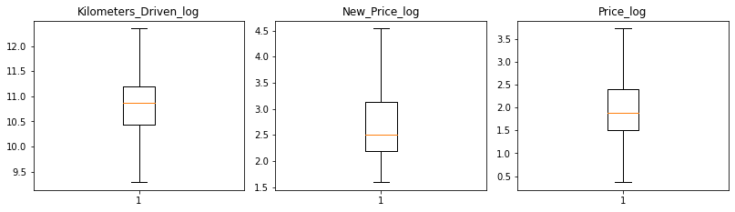

```python
# outlier detection using boxplot
# selecting the numerical columns where outliers were treated
numeric_columns = ['Kilometers_Driven_log','New_Price_log','Price_log']
plt.figure(figsize=(15, 12))

for i, variable in enumerate(numeric_columns):
    plt.subplot(4, 4, i + 1)
    plt.boxplot(df2[variable], whis=1.5)
    plt.tight_layout()
    plt.title(variable)

plt.show()
```

#### Handling Outlier for Seats

```python
df2.drop(df2.index[(df2['Seats']<2)],axis=0,inplace=True)
```

```python
df2[df2['Seats']<2]
```

|  | Location | Year | Fuel_Type | Transmission | Owner_Type | Mileage | Seats | Engine_CC | Power_num | Kilometers_Driven_log | New_Price_log | Price_log |
| --- | --- | --- | --- | --- | --- | --- | --- | --- | --- | --- | --- | --- |

- Columns where we intended to deal with outliers have been successfully dealt with
- Our new boxplot above gives us that evidence
- The seats column also has no car with seats less than 2 anymore.
- We have successfully dealt with Outliers

### MODEL BUILDING

```python
df3 = df2.copy()
```

#### Dependent Variables

```python
X = df3.drop(["Price_log"], axis=1)
y = df3["Price_log"]
```

```python
df3.head(2)
```

|  | Location | Year | Fuel_Type | Transmission | Owner_Type | Mileage | Seats | Engine_CC | Power_num | Kilometers_Driven_log | New_Price_log | Price_log |
| --- | --- | --- | --- | --- | --- | --- | --- | --- | --- | --- | --- | --- |
| 0 | Mumbai | 2010 | CNG | Manual | First | 37.24 | 5.0 | 998.0 | 58.16 | 11.184435 | 1.873339 | 1.011601 |
| 1 | Pune | 2015 | Diesel | Manual | First | 19.60 | 5.0 | 1582.0 | 126.20 | 10.621352 | 2.836737 | 2.602690 |

#### Creating dummy variables

```python
X = pd.get_dummies(
    X,
    columns=X.select_dtypes(include=["object","category"]).columns.tolist(),
    drop_first=True,
)

X.head()
```

|  | Year | Mileage | Seats | Engine_CC | Power_num | Kilometers_Driven_log | New_Price_log | Location_Bangalore | Location_Chennai | Location_Coimbatore | Location_Delhi | Location_Hyderabad | Location_Jaipur | Location_Kochi | Location_Kolkata | Location_Mumbai | Location_Pune | Fuel_Type_Diesel | Fuel_Type_LPG | Fuel_Type_Petrol | Transmission_Manual | Owner_Type_Fourth & Above | Owner_Type_Second | Owner_Type_Third |
| --- | --- | --- | --- | --- | --- | --- | --- | --- | --- | --- | --- | --- | --- | --- | --- | --- | --- | --- | --- | --- | --- | --- | --- | --- |
| 0 | 2010 | 37.24 | 5.0 | 998.0 | 58.16 | 11.184435 | 1.873339 | 0 | 0 | 0 | 0 | 0 | 0 | 0 | 0 | 1 | 0 | 0 | 0 | 0 | 1 | 0 | 0 | 0 |
| 1 | 2015 | 19.60 | 5.0 | 1582.0 | 126.20 | 10.621352 | 2.836737 | 0 | 0 | 0 | 0 | 0 | 0 | 0 | 0 | 0 | 1 | 1 | 0 | 0 | 1 | 0 | 0 | 0 |
| 2 | 2011 | 18.00 | 5.0 | 1199.0 | 88.70 | 10.736418 | 2.262804 | 0 | 1 | 0 | 0 | 0 | 0 | 0 | 0 | 0 | 0 | 0 | 0 | 1 | 1 | 0 | 0 | 0 |
| 3 | 2012 | 20.70 | 7.0 | 1248.0 | 88.76 | 11.373675 | 2.507157 | 0 | 1 | 0 | 0 | 0 | 0 | 0 | 0 | 0 | 0 | 1 | 0 | 0 | 1 | 0 | 0 | 0 |
| 4 | 2013 | 15.00 | 5.0 | 1968.0 | 140.80 | 10.613271 | 3.991573 | 0 | 0 | 1 | 0 | 0 | 0 | 0 | 0 | 0 | 0 | 1 | 0 | 0 | 0 | 0 | 1 | 0 |

```python
from sklearn.model_selection import train_test_split

x_train, x_test, y_train, y_test = train_test_split(X, y, test_size=0.3, random_state=1)
```

```python
print("Number of rows in train data =", x_train.shape[0])
print("Number of rows in test data =", x_test.shape[0])
```

```
Number of rows in train data = 4211
Number of rows in test data = 1805
```

### Fitting a linear model

```python
lin_reg_model = LinearRegression()
lin_reg_model.fit(x_train, y_train)
```

```
LinearRegression()
```

### Model performance check

- We will be using metric functions defined in sklearn for RMSE, MAE, and 𝑅2.
- We will define functions to calculate adjusted 𝑅 and MAPE.
- The mean absolute percentage error (MAPE) measures the accuracy of predictions as a percentage, and can be calculated as the average absolute percent error for each predicted value minus actual values divided by actual values. It works best if there are no extreme values in the data and none of the actual values are 0.
- We will create a function that will print out all the above metrics in one go.

```python
# function to compute adjusted R-squared
def adj_r2_score(predictors, targets, predictions):
    r2 = r2_score(targets, predictions)
    n = predictors.shape[0]
    k = predictors.shape[1]
    return 1 - ((1 - r2) * (n - 1) / (n - k - 1))


# function to compute MAPE
def mape_score(targets, predictions):
    return np.mean(np.abs(targets - predictions) / targets) * 100


# function to compute different metrics to check performance of a regression model
def model_performance_regression(model, predictors, target):
    """
    Function to compute different metrics to check regression model performance

    model: regressor
    predictors: independent variables
    target: dependent variable
    """

    # predicting using the independent variables
    pred = model.predict(predictors)

    r2 = r2_score(target, pred)  # to compute R-squared
    adjr2 = adj_r2_score(predictors, target, pred)  # to compute adjusted R-squared
    rmse = np.sqrt(mean_squared_error(target, pred))  # to compute RMSE
    mae = mean_absolute_error(target, pred)  # to compute MAE
    mape = mape_score(target, pred)  # to compute MAPE

    # creating a dataframe of metrics
    df_perf = pd.DataFrame(
        {
            "RMSE": rmse,
            "MAE": mae,
            "R-squared": r2,
            "Adj. R-squared": adjr2,
            "MAPE": mape,
        },
        index=[0],
    )

    return df_perf
```

```python
# Checking model performance on train set
print("Training Performance\n")
lin_reg_model_train_perf = model_performance_regression(lin_reg_model, x_train, y_train)
lin_reg_model_train_perf
```

```
Training Performance
```

|  | RMSE | MAE | R-squared | Adj. R-squared | MAPE |
| --- | --- | --- | --- | --- | --- |
| 0 | 0.203499 | 0.152188 | 0.921806 | 0.921358 | 9.10782 |

```python
# Checking model performance on test set
print("Test Performance\n")
lin_reg_model_test_perf = model_performance_regression(lin_reg_model, x_test, y_test)
lin_reg_model_test_perf
```

```
Test Performance
```

|  | RMSE | MAE | R-squared | Adj. R-squared | MAPE |
| --- | --- | --- | --- | --- | --- |
| 0 | 0.21362 | 0.154047 | 0.913371 | 0.912203 | 9.377941 |

#### Observations

- The train and test 𝑅2 are 0.92 and 0.91, indicating that the model explains 92% and 91% of the total variation in the train and test sets respectively. Also, both scores are comparable.
- RMSE values on the train and test sets are also comparable.
- This shows that the model is not overfitting.
- MAE indicates that our current model is able to predict Price within a mean error of 0.15 on the test set.
- MAPE of 9.37 on the test data means that we are able to predict within ~9.37% of the Price.